# ATP Tennis Match Prediction

[figure not shown]

## Overview

In this notebook, we will try to conduct a full Data Science & ML Study of the ATP dataset to predict the outcome of the matches in the year 2017. The study will include :

- Some exploratory data analysis through questions/answers
- The data preparation process (Missing values imputation..)
- The modeling phase (Feature Engineering, Model Tuning..)

## DataSet

The website http://tennis-data.co.uk/alldata.php gathers outcomes of ATP (Association of Tennis Professionals - men only) tennis games over several years (From year 2000). A short description of each variable can be found here : http://www.tennis-data.co.uk/notes.txt

```python
import pandas as pd
from urllib.request import urlopen
import os.path as osp
import os
import logging
import zipfile
from glob import glob
logging.getLogger().setLevel('INFO')
```

## Helpers

```python
def download_file(url_str, path):
    url = urlopen(url_str)
    output = open(path, 'wb')
    output.write(url.read())
    output.close()

def extract_file(archive_path, target_dir):
    zip_file = zipfile.ZipFile(archive_path, 'r')
    zip_file.extractall(target_dir)
    zip_file.close()
```

## Download the dataset

```python
BASE_URL = 'http://tennis-data.co.uk'
DATA_DIR = "tennis_data"
ATP_DIR = './{}/ATP'.format(DATA_DIR)

ATP_URLS = [BASE_URL + "/%i/%i.zip" % (i,i) for i in range(2000,2019)]

os.makedirs(osp.join(ATP_DIR, 'archives'), exist_ok=True)

for files, directory in ((ATP_URLS,ATP_DIR),(ATP_URLS,ATP_DIR)):
    for dl_path in files:
        logging.info("downloading & extracting file %s", dl_path)
        archive_path = osp.join(directory, 'archives', osp.basename(dl_path))
        download_file(dl_path, archive_path)
        extract_file(archive_path, directory)

ATP_FILES = sorted(glob("%s/*.xls*" % ATP_DIR))

df_atp = pd.concat([pd.read_excel(f) for f in ATP_FILES], ignore_index=True)

logging.info("%i matches ATP in df_atp", df_atp.shape[0])
```

[output not shown]

# Exploratory Data Analysis through questions

In this section, we will try to ask and respond to some questions to get used to the problem and gain some insights.

```python
import numpy as np
import re    #Regular Expression module for string manipulation
import plotnine as pln #Plotting library (implementation of R's ggplot2)
from matplotlib import pyplot as plt
import seaborn as sns
sns.set(style="darkgrid")
```

### Q1) **Who are the three ATP players with the most wins ?**

A quick exploration of the "Winner" feature in our data shows that names take the form **'XXX Y.'**. Still, some observations have an aditional space **'XXX Y. '**. So the first thing to do is to correct these exceptions.

```python
reCorr1 = lambda s: re.sub(string = s, pattern=" $", repl="")
```

```python
df_atp.loc[:,'Winner'] = df_atp.loc[:,'Winner'].apply(reCorr1)
```

```python
winnersCount = df_atp['Winner'].value_counts()
```

```python
winnersCount.sort_values(ascending=False).head(3)
```

```
Federer R.     1115
Nadal R.        891
Djokovic N.     799
Name: Winner, dtype: int64
```

So the players with the most wins are :  
1 - Federer R.  
2 - Nadal R.  
2 - Djokovic N.

### Q2) **How many sets did the player “Federer R.” win in total ?**

1- First, we filter the observations that include our player 'Federer R.', whether he's the winner or the loser.  
2- We select the features we're going to use for this question : 'Wsets','Lsets','Winner'.  
3- We check/clean the 'Wsets' & 'Lsets' features and turn their values into numerical values.  
4- Finally, we can do the summation of the number of won sets.

```python
#Subset of Matches having 'Federer R.' as a player
FedIndexes = (df_atp.Winner=='Federer R.')| (df_atp.Loser=='Federer R.')
FedererSub = df_atp.loc[FedIndexes,['Wsets','Lsets','Winner']]
```

```python
#Re-setting the dataframe indexes
FedererSub.reset_index(inplace=True)
del(FedererSub['index'])
FedererSub = FedererSub.astype(dtype='str')
FedererSub.head()
```

|  | Wsets | Lsets | Winner |
| --- | --- | --- | --- |
| 0 | 2.0 | 0 | Federer R. |
| 1 | 2.0 | 0 | Enqvist T. |
| 2 | 2.0 | 0 | Ferrero J.C. |
| 3 | 3.0 | 0 | Federer R. |
| 4 | 3.0 | 0 | Federer R. |

```python
print("Unique values in Wsets feature : "+ str(FedererSub.loc[:,'Wsets'].unique()))
print("Unique values in Lsets feature : "+ str(FedererSub.loc[:,'Lsets'].unique()))
```

```
Unique values in Wsets feature : ['2.0' '3.0' '1.0' '0.0' 'nan']
Unique values in Lsets feature : ['0' '1' '2' '1.0' '0.0' '2.0' 'nan' '`1']
```

```python
#Define a
c1,c2,c3 = ".","nan","`"
def toInt(s):
    """
    Overview :
    Helper function for strings cleaning + to integer transformation

    Arguments :
    - s : String

    Returns :
    - Integer number in String s

    """
    if(c1 in s):
        s = int(float(s))
        return(s)
    elif(c2 in s):
        s=0
        return(s)
    elif(c3 in s):
        s = int(s.replace(c3,""))
        return(s)
    else:
        s = int(s)
        return(s)
```

```python
FedererWSets = 0
for i,val in enumerate(FedererSub['Winner']):
    if(val=="Federer R."):
        FedererWSets += toInt(FedererSub.loc[i,'Wsets'])
    else:
        FedererWSets += toInt(FedererSub.loc[i,'Lsets'])
```

```python
FedererWSets
```

```
2685
```

### Q3) **How many sets did the player “Federer R.” win during the years 2016 and 2017 ?**

1 - Filter the rows with date in (2016,2017) and exploit the previous 'Federer R.' indexes to obtain the subset.  
2 - We do the same as before (Step 2->4)

```python
#Quick exploration of the 'Date' variable
df_atp['Date'].describe()
```

```
count                   52174
unique                   4628
top       2002-08-26 00:00:00
freq                      127
first     2000-01-03 00:00:00
last      2018-10-21 00:00:00
Name: Date, dtype: object
```

```python
#Selecting indexes
sub1 = lambda x: x.year in (2016,2017)
FedIndexes1617 = df_atp['Date'].apply(sub1)
```

```python
#Intersection with the previous indexes of Federer's observations => Federer + (2016,2017)
FedIndexes1617 = (FedIndexes1617 & FedIndexes)
```

```python
#Selecting feautures
FedererSub1617 = df_atp.loc[FedIndexes1617, ['Wsets','Lsets','Winner']].copy()
FedererSub1617.shape
```

```
(86, 3)
```

```python
#Re-indexing data
FedererSub1617.reset_index(inplace=True)
del(FedererSub1617['index'])
FedererSub1617 = FedererSub1617.astype(dtype='str')
```

```python
FedererWSets1617 = 0
for i, val in enumerate(FedererSub1617['Winner']):
    if (val == "Federer R."):
        FedererWSets1617 += toInt(FedererSub1617.loc[i,'Wsets'])
    else:
        FedererWSets1617 += toInt(FedererSub1617.loc[i,'Lsets'])
```

```python
FedererWSets1617
```

```
182
```

So "Federer R." won **182** set in the ATP matches of 2016 & 2017.

### Q4)**For each match, what is the percentage of victories of the winner in the past ?**

If we call 'victory' during a given match a game won in a certain set of that match, then the percentage of victories of the winner in the past is expressed as the ratio :  
\begin{equation*} \frac{W1+W2+W3+W4+W5}{W1+W2+W3+W4+W5+L1+L2+L3+L4+L5} \end{equation*} To calculate it, we need to :  
1 - Select 'Wi' and 'Li' columns (i in 1:5).  
2 - Drop observations having NAs in the first Set of the match.  
3 - Clean values in the selected features (nan, blank spaces..).  
4 - Compute the ration for each observation.

```python
#Select the columns names
names = df_atp.columns
setColumns = names[[bool(re.search(r"([WL][1-5])",name)) for name in names]]
setColumns
```

```
Index(['L1', 'L2', 'L3', 'L4', 'L5', 'W1', 'W2', 'W3', 'W4', 'W5'], dtype='object')
```

```python
#Subset the data with the columns names
df_atp_sub = df_atp.loc[:,setColumns].copy()
```

```python
df_atp_sub.head()
```

|  | L1 | L2 | L3 | L4 | L5 | W1 | W2 | W3 | W4 | W5 |
| --- | --- | --- | --- | --- | --- | --- | --- | --- | --- | --- |
| 0 | 4.0 | 2 | NaN | NaN | NaN | 6.0 | 6 | NaN | NaN | NaN |
| 1 | 3.0 | 3 | NaN | NaN | NaN | 6.0 | 6 | NaN | NaN | NaN |
| 2 | 7.0 | 5 | 3 | NaN | NaN | 6.0 | 7 | 6 | NaN | NaN |
| 3 | 1.0 | 4 | NaN | NaN | NaN | 6.0 | 6 | NaN | NaN | NaN |
| 4 | 6.0 | 7 | 4 | NaN | NaN | 7.0 | 5 | 6 | NaN | NaN |

```python
#Find indexes with missing values in the first set (W1 or L1)
naIndexes = df_atp_sub['W1'].isna() | df_atp_sub['L1'].isna()
cleanIndexes = naIndexes.apply(lambda e : not e)
```

```python
#Filter data with cleanIndexes
df_atp_sub = df_atp_sub.loc[cleanIndexes,:]
```

```python
#Unique values in Wi features (i in 1:5)
pd.concat([df_atp_sub.W1,df_atp_sub.W2, df_atp_sub.W3, df_atp_sub.W4, df_atp_sub.W5]).unique()
```

```
array([6.0, 7.0, 3.0, 4.0, 2.0, 5.0, 0.0, 1.0, nan, ' ', 10.0, 9.0, 8.0,
       13.0, 12.0, 20.0, 11.0, 21.0, 16.0, 15.0, 14.0, 17.0, 70.0, 18.0,
       19.0, 22.0, 26.0], dtype=object)
```

```python
#Unique values in Li features (i in 1:5)
pd.concat([df_atp_sub.L1,df_atp_sub.L2, df_atp_sub.L3, df_atp_sub.L4, df_atp_sub.L5]).unique()
```

```
array([4.0, 3.0, 7.0, 1.0, 6.0, 2.0, 0.0, 5.0, nan, ' ', 8.0, 11.0, 10.0,
       18.0, 9.0, 19.0, 14.0, 13.0, 12.0, 15.0, 68.0, 16.0, 17.0, 20.0,
       24.0], dtype=object)
```

Since the values are not all numerical, we'll need to deal with the special cases and avoid including nan values in the summation.

```python
#Function : handles missing values/special cases + calculates the winning percentage
def WinPercentage(obs):
    myobs = obs.copy()
    myobs[myobs == ' '] = np.nan
    wins = np.nansum(myobs['W1':'W5'])
    loses = np.nansum(myobs['L1':'L5'])
    if wins+loses == 0:
        return(0)
    else:
        per = 100*wins/(wins+loses)
        return(per)
```

```python
#Execution will take about 2 minutes
df_win_per = df_atp_sub.apply(axis=1, func=WinPercentage)
```

```python
df_win_per = pd.DataFrame({'Wper':df_win_per})
df_win_per.describe(include='all')
```

|  | Wper |
| --- | --- |
| count | 51914.000000 |
| mean | 61.913378 |
| std | 8.635817 |
| min | 0.000000 |
| 25% | 56.000000 |
| 50% | 60.000000 |
| 75% | 66.666667 |
| max | 100.000000 |

The best way to represent these results is to use a density plot (or a histogramm) :

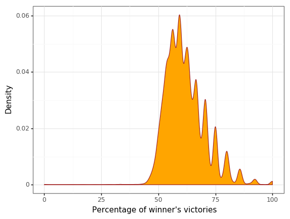

```python
pln.ggplot(data=df_win_per, mapping=pln.aes(x='Wper'))+pln.geom_density(colour="brown", fill="orange")+pln.theme_bw()+pln.xlab("")+pln.ylab("Density")+pln.xlab("Percentage of winner's victories")
```

We can have a "look from above" of our density plot using a boxplot :

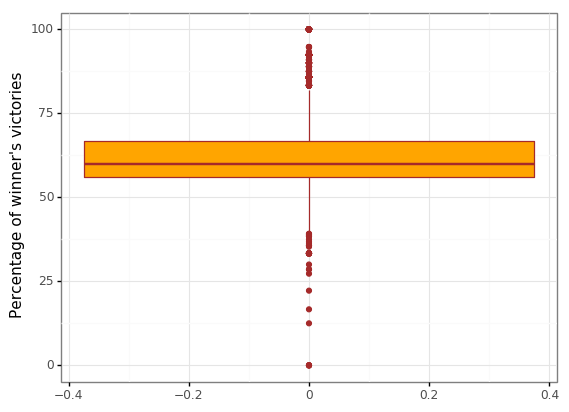

```python
pln.ggplot(data=df_win_per, mapping=pln.aes(x='0',y='Wper'))+pln.geom_boxplot(colour="brown", fill="orange")+pln.theme_bw()+pln.xlab("")+pln.ylab("Percentage of winner's victories")
```

So in average, the percentage of victories for a winner in the past is equal in average to about **62%** which makes sense since its > 50%.  
Still, even if the results show that more than 75% (3rd quartile) of the cases have a winning percentage > 50%, some observations lay bellow this tresh-hold (about 2%). One explanation to this is the absence of complete scores for some matches, or the player withdrawal/retirement during the match, the 'Comment' feature can be used to check this hypothesis.

```python
print("Abberant observations : "+ str(round(sum(df_win_per.Wper<50)/len(df_win_per), 3)))
```

```
Abberant observations : 0.022
```

**Aditional Part**  
If we call 'victory' during a given match a **Set** won in that match, then the percentage of victories of the winner in the past is expressed as the ratio :  
\begin{equation*} \frac{Wsets}{Wsets+Lsets} \end{equation*}  
In this case, we'll follow almost the same steps as before

```python
#Select the columns names
columns_2 = ['Wsets','Lsets']
```

```python
df_atp_sub_2 = df_atp.loc[:,columns_2].copy()
```

```python
df_atp_sub_2.head()
```

|  | Wsets | Lsets |
| --- | --- | --- |
| 0 | 2.0 | 0 |
| 1 | 2.0 | 0 |
| 2 | 2.0 | 1 |
| 3 | 2.0 | 0 |
| 4 | 2.0 | 1 |

```python
#Find indexes with missing values in the first set (W1 or L1)
naIndexes_2 = df_atp_sub_2['Wsets'].isna() | df_atp_sub_2['Lsets'].isna()
cleanIndexes_2 = naIndexes_2.apply(lambda e : not e)
```

```python
sum(cleanIndexes_2)
```

```
51951
```

```python
len(df_atp_sub_2)
```

```
52174
```

```python
#Filter data with cleanIndexes
df_atp_sub_2 = df_atp_sub_2.loc[cleanIndexes_2,:]
```

```python
#Unique values in Li features (i in 1:5)
pd.concat([df_atp_sub_2.Lsets, df_atp_sub_2.Wsets]).unique()
```

```
array([0, 1, 2, '`1', 3.0], dtype=object)
```

```python
#Function : handles missing values/special caracters + calculates the winning percentage
def WinPercentage2(obs):
    myobs = obs.copy()
    myobs[myobs == '`1'] = 1
    wins = np.nansum(myobs['Wsets'])
    loses = np.nansum(myobs['Lsets'])
    if wins+loses == 0:
        return(0)
    else:
        per = 100*wins/(wins+loses)
        return(per)
```

```python
#Execution will take about 2 minutes
df_win_per_2 = df_atp_sub_2.apply(axis=1, func=WinPercentage2)
```

```python
df_win_per_2 = pd.DataFrame({'Wper':df_win_per_2})
df_win_per_2.describe(include='all')
```

|  | Wper |
| --- | --- |
| count | 51951.000000 |
| mean | 86.939199 |
| std | 17.906833 |
| min | 0.000000 |
| 25% | 66.666667 |
| 50% | 100.000000 |
| 75% | 100.000000 |
| max | 100.000000 |

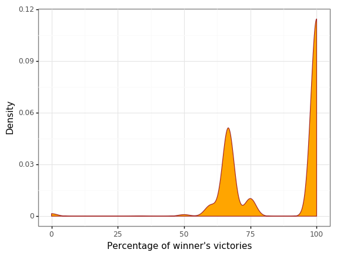

```python
pln.ggplot(data=df_win_per_2, mapping=pln.aes(x='Wper'))+pln.geom_density(colour="brown", fill="orange")+pln.theme_bw()+pln.xlab("")+pln.ylab("Density")+pln.xlab("Percentage of winner's victories")
```

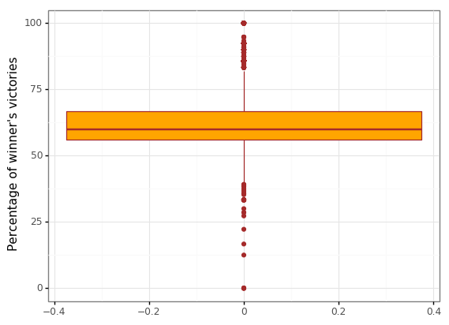

```python
pln.ggplot(data=df_win_per, mapping=pln.aes(x='0',y='Wper'))+pln.geom_boxplot(colour="brown", fill="orange")+pln.theme_bw()+pln.xlab("")+pln.ylab("Percentage of winner's victories")
```

When comparing Sets results to single games, we get more insights, let's look at both distribution informations :

```python
pd.concat([df_win_per,df_win_per_2], axis=1).describe()
```

|  | Wper | Wper |
| --- | --- | --- |
| count | 51914.000000 | 51951.000000 |
| mean | 61.913378 | 86.939199 |
| std | 8.635817 | 17.906833 |
| min | 0.000000 | 0.000000 |
| 25% | 56.000000 | 66.666667 |
| 50% | 60.000000 | 100.000000 |
| 75% | 66.666667 | 100.000000 |
| max | 100.000000 | 100.000000 |

Match winners win on average **87% of the Sets** but just **62% of the Games**. A simple explanation for that is the scoring system : you have to win 6 games to get 1 Set, we can look at the Set result as an average of the 6 (or more) played games, and thus it represents the overall performance of the player, while single games are 'less' general and thus they fluctuate more, and generally a player can't win many consecutive games. Besides, another explanation is that Set results are somehow more crutial since they are directly linked to match final result, while games results come in a second level far from the final result.  
**hint**  
This issue of ensemble probability Vs time probability reminds me of an article by Nassim Nicholas Taleb on Medium. You can check it if you want to : https://medium.com/incerto/the-logic-of-risk-taking-107bf41029d3

# Data Preparation

## Data Splitting

```python
usedColumns = ['Best of',
'Court',
'Date',
'LPts',
 'LRank',
'Loser',
 'Round',
 'Series',
 'Surface',
 'Tournament',
'WPts',
 'WRank',
 'Winner']
```

```python
#Preparing rows indexes for splitting (Train-Test)
gTest = lambda x: x.year == 2017
gTrain = lambda x: x.year < 2017
testInd = df_atp['Date'].apply(gTest)
trainInd = df_atp['Date'].apply(gTrain)
```

```python
#Splitting data (Train - Test)
df_atp_Train = df_atp.loc[trainInd, usedColumns].copy()
df_atp_Test = df_atp.loc[testInd, usedColumns].copy()
print("Shape of atp data : a)Train = "+str(df_atp_Train.shape)+ " ; b)Test = "+str(df_atp_Test.shape))
```

```
Shape of atp data : a)Train = (47028, 13) ; b)Test = (2635, 13)
```

```python
df_atp_Train.describe(include='all')
```

|  | Best of | Court | Date | LPts | LRank | Loser | Round | Series | Surface | Tournament | WPts | WRank | Winner |
| --- | --- | --- | --- | --- | --- | --- | --- | --- | --- | --- | --- | --- | --- |
| count | 47028.00000 | 47028 | 47028 | 30772.000000 | 46957.0 | 47028 | 47028 | 47028 | 47028 | 47028 | 30824.000000 | 47013.0 | 47028 |
| unique | NaN | 2 | 4087 | NaN | 924.0 | 1385 | 8 | 8 | 4 | 206 | NaN | 586.0 | 849 |
| top | NaN | Outdoor | 2000-05-29 00:00:00 | NaN | 46.0 | Lopez F. | 1st Round | International | Hard | French Open | NaN | 1.0 | Federer R. |
| freq | NaN | 38521 | 127 | NaN | 415.0 | 370 | 21848 | 12204 | 24710 | 2159 | NaN | 1077.0 | 1023 |
| first | NaN | NaN | 2000-01-03 00:00:00 | NaN | NaN | NaN | NaN | NaN | NaN | NaN | NaN | NaN | NaN |
| last | NaN | NaN | 2016-11-20 00:00:00 | NaN | NaN | NaN | NaN | NaN | NaN | NaN | NaN | NaN | NaN |
| mean | 3.37097 | NaN | NaN | 1033.792604 | NaN | NaN | NaN | NaN | NaN | NaN | 1845.345672 | NaN | NaN |
| std | 0.77739 | NaN | NaN | 1222.460585 | NaN | NaN | NaN | NaN | NaN | NaN | 2360.801597 | NaN | NaN |
| min | 3.00000 | NaN | NaN | 1.000000 | NaN | NaN | NaN | NaN | NaN | NaN | 1.000000 | NaN | NaN |
| 25% | 3.00000 | NaN | NaN | 490.000000 | NaN | NaN | NaN | NaN | NaN | NaN | 631.000000 | NaN | NaN |
| 50% | 3.00000 | NaN | NaN | 726.000000 | NaN | NaN | NaN | NaN | NaN | NaN | 1000.000000 | NaN | NaN |
| 75% | 3.00000 | NaN | NaN | 1125.000000 | NaN | NaN | NaN | NaN | NaN | NaN | 1875.000000 | NaN | NaN |
| max | 5.00000 | NaN | NaN | 16950.000000 | NaN | NaN | NaN | NaN | NaN | NaN | 16950.000000 | NaN | NaN |

# Data Preprocessing

```python
from sklearn.linear_model import LinearRegression
from sklearn.preprocessing import PolynomialFeatures

#Import Random Forest Model
from sklearn.ensemble import RandomForestClassifier, RandomForestRegressor
from sklearn.model_selection import RandomizedSearchCV
```

## 1 - Missing Values Imputation

### 1.1 - Overview of data missing values

We start by examining columns with missing values. The columns with the most NA's are those Points related.

```python
print("Percentage of missing values in WPts column : " + str(np.round(100*np.sum(df_atp_Train.WPts.isna())/len(df_atp_Train), 3))+"%")
print("Percentage of missing values in LPts column : " + str(np.round(100*np.sum(df_atp_Train.LPts.isna())/len(df_atp_Train), 3))+"%")
```

```
Percentage of missing values in WPts column : 34.456%
Percentage of missing values in LPts column : 34.567%
```

A quick exploration of the unique values in 'WRank' and 'LRank' shows that there are 3 types of values : **Numerical, 'NR', and nan**. We first turn 'NR' (*Not recognized*) to np.NaN to deal with it as a missing value.

```python
naRankIndW = df_atp_Train.loc[:,'WRank'].apply(lambda x: x=='NR')
naRankIndL = df_atp_Train.loc[:,'LRank'].apply(lambda x: x=='NR')
df_atp_Train.loc[naRankIndW,'WRank'] = np.NaN
df_atp_Train.loc[naRankIndL,'LRank'] = np.NaN
```

```python
print("Number of missing values in WRank column : " + str(np.sum(df_atp_Train.WRank.isna())))
print("Number of missing values in LRank column : " + str(np.sum(df_atp_Train.LRank.isna())))
```

```
Number of missing values in WRank column : 16
Number of missing values in LRank column : 98
```

Fortunately, 'Date' column is clear with no missing values.

```python
print("Number of missing values in Date column : " + str(np.sum(df_atp_Train.Date.isna())))
```

```
Number of missing values in Date column : 0
```

### 1.2 - Imputation of Rank-related missing values

We start by imputing the Rank-related missing values since they are less frequent, using a per-player linear regression model modeling Rank = f(Date). We'll use these values later to impute Points-related values since there is a large correlation between players' rankings and points (Ranking is by definition based on Points).  
To do so, we distinguish two separate cases :

- **Players having some non-NA (date,rank) observations** : in this case, we will fit a simple linear regression model to interpolate the missing ranks.
- **Players having no recorded (date,rank) observation** : in this case, we will impute the median value of winners' ranks and losers' rank for winner and loser cases respectively.

We'll try to see some per-player Date - Rank relationship.

```python
myPlayer = 'Federer R.'
```

```python
winData = df_atp_Train.loc[df_atp_Train.Winner==myPlayer,['Date', 'WRank']]
loseData = df_atp_Train.loc[df_atp_Train.Loser==myPlayer,['Date','LRank']]

RankData = pd.DataFrame({'Date':pd.concat([winData.Date, loseData.Date], axis=0),
                             'Rank':pd.concat([winData.WRank, loseData.LRank], axis=0)})
RankData.sort_index(axis=0, inplace=True)
```

```python
RankData['Date'] = RankData['Date'].apply(lambda x : x.year +(x.month-1)/12)
```

```python
RankData.dropna(inplace=True)
```

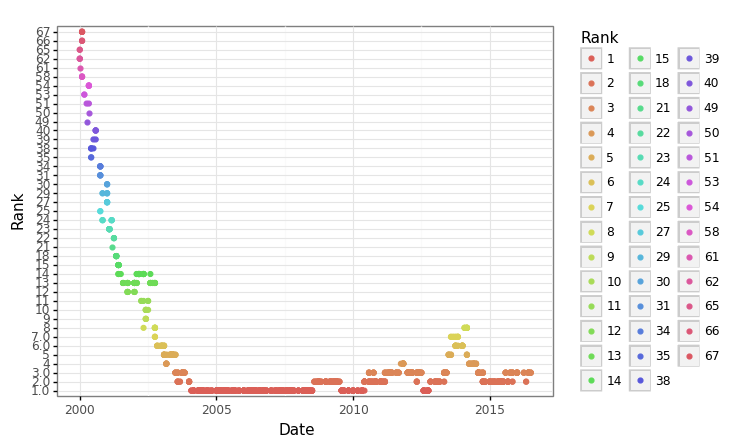

```python
pln.ggplot(RankData, pln.aes(x='Date', y='Rank'))+pln.geom_point(pln.aes(colour='Rank'))+pln.theme_bw()
```

The shape of the time serie varies of course from a player to another one. One simple way to model this relationship is using a polynomial regression with a degree depending on the size of available data of the given player.

```python
weights_date_rank = np.polyfit(RankData.Date, RankData.Rank, 3)
model_date_rank = np.poly1d(weights_date_rank)
preds_rank = np.round(model_date_rank(RankData.Date))
preds_rank[preds_rank<1] = 1
```

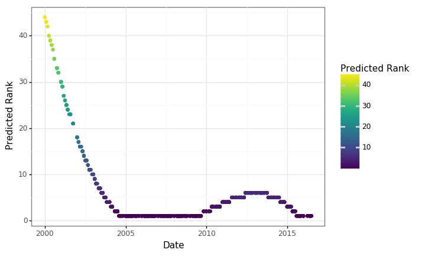

```python
ggDateRankex = pln.ggplot(data = pd.DataFrame({'Date':RankData.Date,'Predicted Rank':preds_rank}))
ggDateRankex + pln.geom_point(pln.aes(x='Date',y='Predicted Rank',colour= 'Predicted Rank'))+ pln.theme_bw()
```

The fitted model seems to be close enough to the true shape. We will use it for the whole set of players to impute the missing values of ranks.

```python
#Players having missing ranks:
df_nan_RanksW = df_atp_Train.loc[df_atp_Train.WRank.isna(),['Date','Winner']].copy()
df_nan_RanksL = df_atp_Train.loc[df_atp_Train.LRank.isna(),['Date','Loser']].copy()
Trues0 = np.repeat(True, repeats=df_nan_RanksW.shape[0], axis=0)
Falses0 = np.repeat(False, repeats=df_nan_RanksL.shape[0], axis=0)
```

```python
#Dataframe putting together all the players with NA's in Rank + Date of match + whether it's a winner or not
df_nan_Ranks = pd.DataFrame({'Date':pd.concat([df_nan_RanksW['Date'], df_nan_RanksL['Date']], axis=0),
                          'Player' : pd.concat([df_nan_RanksW['Winner'],df_nan_RanksL['Loser']], axis=0),
                         'isWinner':pd.Series(np.concatenate([Trues0,Falses0]).flatten(),
                                            index=np.concatenate([df_nan_RanksW.index, df_nan_RanksL.index]))
                         })
df_nan_Ranks.sort_index(ascending=True, inplace=True)
```

```python
df_nan_Ranks['DateFloat'] = df_nan_Ranks['Date'].apply(lambda x : x.year + (x.month-1)/12 + x.day/365)
```

```python
df_nan_Ranks.head()
```

|  | Date | Player | isWinner | DateFloat |
| --- | --- | --- | --- | --- |
| 63 | 2000-01-03 | Al-Alawi S.K. | False | 2000.008219 |
| 377 | 2000-02-14 | Jensen L. | False | 2000.121689 |
| 560 | 2000-02-28 | Roddick A. | False | 2000.160046 |
| 611 | 2000-03-06 | Gonzalez P. | False | 2000.183105 |
| 613 | 2000-03-06 | Hadad M. | False | 2000.183105 |

```python
#Preparing median values for rank-imputations in case 2 :
medianRankW = np.median(df_atp_Train['WRank'])
print("Winners' median rank : "+str(medianRankW))
medianRankL = np.median(df_atp_Train['LRank'])
print("Losers' median rank : "+str(medianRankL))
```

```
Winners' median rank : 41.0
Losers' median rank : 65.0
```

```python
def genMedianRank(lenWin, lenLose, medianRankW = medianRankW, medianRankL =medianRankL):
    """
    -Overview :
    Rank Imputation function for case 2 players

    - Arguments :
    lenWin , lenLose : number of won/lost matches for a given player
    medianRankW , medianRankL :  Rank medians (Winner/Loser)

    - Returns :
    numpy array of juxtaposed Rank medians (Winner/Loser) . This will serve as an imputation vector (shape : (lenWin+lenLose))
    """
    return(np.concatenate([np.repeat(medianRankW, repeats=lenWin, axis=0),
                           np.repeat(medianRankL, repeats=lenLose, axis=0)]).flatten())
```

In order to handle Rank missing values in the test set, we're going to use the same per player fitted model

```python
def computeRankImput(Player, nanData = df_nan_Ranks ,sourceData = df_atp_Train):
    """
    - Overview :
    Rank Imputations Computing function for both cases (1 & 2)

    - Arguments :
    Player : [str] Player's name
    nanData : [pandas DataFrame] data of players with Rank missing values (plays the role of training data set)
    sourceData : [pandas DataFrame] target dataset to compute imputations (plays the role of test data set)

    - Returns :
    [pandas Data Frame] : subset of nanData for the given Player + computed imputation values
    """

    winData = sourceData.loc[sourceData.Winner==Player,['Date', 'WRank']]
    loseData = sourceData.loc[sourceData.Loser==Player,['Date','LRank']]

    playerNanData = nanData.loc[nanData['Player']==Player,:].copy()

    RankData = pd.DataFrame({'Date':pd.concat([winData.Date, loseData.Date], axis=0),
                             'Rank':pd.concat([winData.WRank, loseData.LRank], axis=0)})
    RankData.sort_index(inplace=True)
    RankData.dropna(inplace=True)
    RankData['Date'] = RankData['Date'].apply(lambda x : x.year + (x.month-1)/12)

    if(RankData.shape[0]==0):
        return(pd.concat([playerNanData, pd.DataFrame({'PredRank':genMedianRank(lenWin=len(winData),lenLose=len(loseData))},
                                                      index=playerNanData.index)], axis=1))

    indToDrop = RankData['Rank'].apply(lambda x : str(x).isalpha())
    indToDrop = indToDrop.index[indToDrop]
    RankData.drop(axis=0,index= indToDrop, inplace=True)

    polyDegree = round(np.log10(len(RankData)))     #polynomial degree depending on how much data we have (log like for example)

    weights_date_rank = np.polyfit(RankData.Date, RankData.Rank, polyDegree)
    model_date_rank = np.poly1d(weights_date_rank)

    prediction = np.round(model_date_rank(playerNanData['DateFloat']))
    prediction[prediction<1] = 1

    result = pd.concat([playerNanData, pd.DataFrame({'PredRank':prediction}, index=playerNanData.index)], axis=1)
    return(result)
```

```python
def imputeRankData(nanData = df_nan_Ranks ,sourceData = df_atp_Train, targetData = df_atp_Train):
    """
    - Overview :
    Inplace Rank Imputation of data passed as sourceData based on computed imputations by the previous function 'computeRankImput'

    -Arguments :
    nanData : [pandas DataFrame] data of players with Rank missing values
    sourceData : [pandas DataFrame] target dataset to be imputed

    -Returns:
    Inplace imputations (no return)
    Prints imputations progress
    """
    progress = 0
    nanPtsLen = len(nanData['Player'].unique())
    tenPer, per = nanPtsLen//10, 0
    for p in nanData['Player'].unique():
        imputations = computeRankImput(Player=p, nanData = nanData ,sourceData = sourceData)
        for i,val in enumerate(imputations['isWinner']):
            imp = imputations.loc[imputations.index[i], 'PredRank']
            if (val): #Winner case
                targetData.loc[imputations.index[i],'WRank'] = imp
            else:     #Loser case
                targetData.loc[imputations.index[i],'LRank'] = imp
        if(per==progress):
            print("Imputations in progress "+str( np.round(100*per/nanPtsLen, decimals=0))+"%")
            per += tenPer
        progress += 1
        if(progress==nanPtsLen):
            print("Done !")
```

```python
imputeRankData(nanData = df_nan_Ranks ,sourceData = df_atp_Train, targetData = df_atp_Train)
```

```
Imputations in progress 0.0%
Imputations in progress 9.0%
Imputations in progress 19.0%
Imputations in progress 28.0%
Imputations in progress 37.0%
Imputations in progress 47.0%
Imputations in progress 56.0%
Imputations in progress 65.0%
Imputations in progress 74.0%
Imputations in progress 84.0%
Imputations in progress 93.0%
Done !
```

```python
print("Number of missing values in WRank column : " + str(sum(df_atp_Train.WRank.isna())))
```

```
Number of missing values in WRank column : 0
```

```python
print("Number of missing values in LRank column : " + str(sum(df_atp_Train.LRank.isna())))
```

```
Number of missing values in LRank column : 0
```

```python
df_atp_Train['WRank'] = df_atp_Train['WRank'].astype('int64')
df_atp_Train['LRank'] = df_atp_Train['LRank'].astype('int64')
```

We do the same for the test data set. This time, we can use even Ranks from Test Data to perform the interpolation (we couldn't do that before because we risk a Data Leakage).

```python
naRankIndWTest = df_atp_Test.loc[:,'WRank'].apply(lambda x: x=='NR')
naRankIndLTest = df_atp_Test.loc[:,'LRank'].apply(lambda x: x=='NR')
df_atp_Test.loc[naRankIndWTest,'WRank'] = np.NaN
df_atp_Test.loc[naRankIndLTest,'LRank'] = np.NaN
```

```python
print("Number of missing values in WRank column (Test data): " + str(sum(df_atp_Test.WRank.isna())))
```

```
Number of missing values in WRank column (Test data): 0
```

```python
print("Number of missing values in LRank column (Test data): " + str(sum(df_atp_Test.LRank.isna())))
```

```
Number of missing values in LRank column (Test data): 6
```

```python
#Players having missing ranks (In test):
df_nan_RanksL_T = df_atp_Test.loc[df_atp_Test.LRank.isna(),['Date','Loser']].copy()
Falses0T = np.repeat(False, repeats=df_nan_RanksL_T.shape[0], axis=0)

#Dataframe putting together all the players with NA's in Rank + Date of match + whether it's a winner or not
df_nan_Ranks_T = pd.DataFrame({'Date':df_nan_RanksL_T['Date'],
                          'Player' : df_nan_RanksL_T['Loser'],
                         'isWinner':pd.Series(Falses0T, index=df_nan_RanksL_T.index)
                         })
df_nan_Ranks_T.sort_index(ascending=True, inplace=True)

df_nan_Ranks_T['DateFloat'] = df_nan_Ranks_T['Date'].apply(lambda x : x.year + (x.month-1)/12)
```

```python
df_nan_Ranks_T
```

|  | Date | Player | isWinner | DateFloat |
| --- | --- | --- | --- | --- |
| 47124 | 2017-01-10 | Sitak A. | False | 2017.000000 |
| 47225 | 2017-01-17 | Haas T. | False | 2017.000000 |
| 47592 | 2017-02-28 | Alawadhi O. | False | 2017.083333 |
| 48235 | 2017-05-22 | Kokkinakis T. | False | 2017.333333 |
| 48310 | 2017-05-30 | Kokkinakis T. | False | 2017.333333 |
| 49286 | 2017-09-25 | Pavic M. | False | 2017.666667 |

```python
imputeRankData(nanData = df_nan_Ranks_T ,sourceData = df_atp, targetData = df_atp_Test)
```

```
Imputations in progress 0.0%
Done !
```

```python
print("Number of missing values in WRank column (Test data): " + str(sum(df_atp_Test.WRank.isna())))
```

```
Number of missing values in WRank column (Test data): 0
```

```python
print("Number of missing values in LRank column (Test data): " + str(sum(df_atp_Test.LRank.isna())))
```

```
Number of missing values in LRank column (Test data): 0
```

Now that we have imputed all the missing values with numerical values, we can cast the Rank related variables to 'int64'.

```python
df_atp_Test['WRank'] = df_atp_Test['WRank'].astype('int64')
df_atp_Test['LRank'] = df_atp_Test['LRank'].astype('int64')
```

### 1.3 - Imputation of Point-related missing values

```python
#Players having missing points :
nanPointsPlayersW = df_atp_Train.loc[df_atp_Train.WPts.isna(),['WRank','Winner']].copy()
nanPointsPlayersL = df_atp_Train.loc[df_atp_Train.LPts.isna(),['LRank','Loser']].copy()
Trues = np.repeat(True, repeats=nanPointsPlayersW.shape[0], axis=0)
Falses = np.repeat(False, repeats=nanPointsPlayersL.shape[0], axis=0)
df_nan_Points = pd.DataFrame({'Player':pd.concat([nanPointsPlayersW['Winner'], nanPointsPlayersL['Loser']], axis=0),
                                 'Rank':pd.concat([nanPointsPlayersW['WRank'], nanPointsPlayersL['LRank']], axis=0),
                                 'isWinner':pd.Series(np.concatenate([Trues,Falses]).flatten(),
                                            index=np.concatenate([nanPointsPlayersW.index, nanPointsPlayersL.index]))})
```

```python
#Preparing data for training the average model Points = f(Rank)
cleanData = df_atp_Train.loc[:,['WRank','LRank','WPts','LPts']].copy()
cleanData.dropna(axis=0, inplace=True)

PtsSerie = pd.concat([cleanData.LPts, cleanData.WPts], axis=0)
RankSeries = pd.concat([cleanData.LRank, cleanData.WRank], axis=0)
df_rank_points = pd.DataFrame({'Rank':RankSeries,'Points': PtsSerie })

df_rank_points.sort_values(axis=0, by='Rank', inplace=True)
```

```python
#How rank-points looks like
df_rank_points.head()
```

|  | Rank | Points |
| --- | --- | --- |
| 47027 | 1 | 11185.0 |
| 27108 | 1 | 14960.0 |
| 27049 | 1 | 15360.0 |
| 27047 | 1 | 15360.0 |
| 27039 | 1 | 15360.0 |

```python
df_rank_points = df_rank_points.groupby('Rank').aggregate('median')
```

```python
df_rank_points.reset_index(inplace=True)
```

```python
df_rank_points.head()
```

|  | Rank | Points |
| --- | --- | --- |
| 0 | 1 | 12040.0 |
| 1 | 2 | 8700.0 |
| 2 | 3 | 6745.0 |
| 3 | 4 | 5715.0 |
| 4 | 5 | 4840.0 |

```python
XRank = df_rank_points.loc[:,'Rank'].values.reshape(-1, 1)
YRank = df_rank_points.loc[:,'Points'].values.reshape(-1, 1)
```

```python
RfRegressor=RandomForestRegressor(n_estimators=2200, random_state=1995, min_samples_leaf=5, max_features=1, criterion='mse' )
```

```python
RfRegressor.fit(XRank, YRank.squeeze())
```

```
RandomForestRegressor(bootstrap=True, criterion='mse', max_depth=None,
           max_features=1, max_leaf_nodes=None, min_impurity_decrease=0.0,
           min_impurity_split=None, min_samples_leaf=5,
           min_samples_split=2, min_weight_fraction_leaf=0.0,
           n_estimators=2200, n_jobs=1, oob_score=False, random_state=1995,
           verbose=0, warm_start=False)
```

```python
predictedPoints = RfRegressor.predict(XRank)
```

```
Text(0.5,1,'True Point values Vs Fitted values')
```

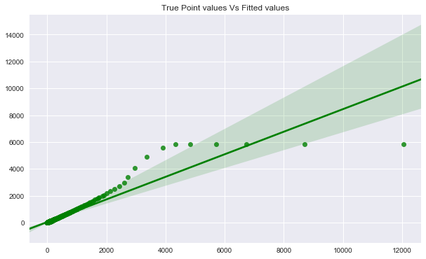

```python
fig, ax = plt.subplots(figsize=(10,6))
sns.regplot(x= YRank.squeeze(), y = predictedPoints, color='green', ax=ax)
plt.title('True Point values Vs Fitted values')
```

```python
pd.DataFrame({'Point':YRank.squeeze()}).quantile(0.98).values
```

```
array([1870.4])
```

More than **98% of Points lay bellow 2000** and thus the model can be used for interpolation

```python
def avgRankPointPred(ranks ,model = RfRegressor):
    """
    -Overview :
    Point Imputations Computing function (based on a pre-trained model passed as argument)

    - Arguments :
    ranks : Player's ranks
    model : Fitted model for Prediction

    - Returns :
    numpy array of predicted points values by the model passed in argument (will serve for imputation)
    """
    myranks = np.array(ranks).reshape((len(ranks),1))
    Ypreds = np.round(model.predict(myranks))
    return(Ypreds)
```

```python
def computePointImput(Player, nanData = df_nan_Points ,targetData = df_atp_Train):
    """
    - Overview :
    Points Imputations Computing function

    - Arguments :
    Player : [str] Player's name
    nanData : [pandas DataFrame] data of players with Points missing values (plays the role of training data set)
    targetData : [pandas DataFrame] target dataset to compute imputations (plays the role of test data set)

    - Returns :
    [pandas Data Frame] : subset of nanData for the given Player + computed imputation values of points
    """

    winData = targetData.loc[targetData.Winner==Player,['WRank', 'WPts']]
    loseData = targetData.loc[targetData.Loser==Player,['LRank','LPts']]

    playerNanData = nanData.loc[nanData['Player']==Player,:].copy()

    PointData = pd.DataFrame({ 'Rank':pd.concat([winData['WRank'], loseData['LRank']], axis=0),
                             'Points':pd.concat([winData['WPts'], loseData['LPts']], axis=0)})
    PointData.sort_index(inplace=True)
    PointData.dropna(inplace=True)
    predPoints = avgRankPointPred(playerNanData['Rank'])
    output = pd.concat([playerNanData, pd.DataFrame({'PredPoint':predPoints}, index=playerNanData.index)], axis=1)
    return(output)
```

```python
def imputePointsData(nanData = df_nan_Points ,targetData = df_atp_Train):
    """
    - Overview :
    Inplace Points Imputation of data passed as targetData based on computed imputations by the previous function 'computePointImput'

    -Arguments :
    nanData : [pandas DataFrame] data of players with Points missing values
    targetData : [pandas DataFrame] target dataset to be imputed

    -Returns:
    Inplace imputations (no return)
    Prints imputations progress
    """
    progress = 0
    nanPtsLen = len(nanData['Player'].unique())
    tenPer, per = nanPtsLen//10, 0
    for p in nanData['Player'].unique():
        imputations = computePointImput(Player=p, nanData = nanData ,targetData = targetData)
        for i,val in enumerate(imputations['isWinner']):
            imp = imputations.loc[imputations.index[i], 'PredPoint']
            if (val): #Winner case
                targetData.loc[imputations.index[i],'WPts'] = imp
            else:     #Loser case
                targetData.loc[imputations.index[i],'LPts'] = imp
        if(per==progress):
            print("Imputations in progress "+str( np.round(100*per/nanPtsLen, decimals=0))+"%")
            per += tenPer
        progress += 1
        if(progress==nanPtsLen):
            print("Done !")
```

```python
imputePointsData(nanData = df_nan_Points ,targetData = df_atp_Train)
```

```
Imputations in progress 0.0%
Imputations in progress 10.0%
Imputations in progress 20.0%
Imputations in progress 30.0%
Imputations in progress 40.0%
Imputations in progress 50.0%
Imputations in progress 60.0%
Imputations in progress 69.0%
Imputations in progress 79.0%
Imputations in progress 89.0%
Imputations in progress 99.0%
Done !
```

```python
print("Percentage of missing values in WPts column : " + str(np.round(100*sum(df_atp_Train.WPts.isna())/len(df_atp_Train), 3))+"%")
print("Percentage of missing values in LPts column : " + str(np.round(100*sum(df_atp_Train.LPts.isna())/len(df_atp_Train), 3))+"%")
```

```
Percentage of missing values in WPts column : 0.0%
Percentage of missing values in LPts column : 0.0%
```

```python
df_atp_Train['WPts'] = df_atp_Train['WPts'].astype('int64')
df_atp_Train['LPts'] = df_atp_Train['LPts'].astype('int64')
```

Quick comparison between some observations before/after na imputation:

```python
df_atp_Train.head()
```

|  | Best of | Court | Date | LPts | LRank | Loser | Round | Series | Surface | Tournament | WPts | WRank | Winner |
| --- | --- | --- | --- | --- | --- | --- | --- | --- | --- | --- | --- | --- | --- |
| 0 | 3 | Outdoor | 2000-01-03 | 648 | 77 | Ljubicic I. | 1st Round | International | Hard | Australian Hardcourt Championships | 755 | 63 | Dosedel S. |
| 1 | 3 | Outdoor | 2000-01-03 | 818 | 56 | Clement A. | 1st Round | International | Hard | Australian Hardcourt Championships | 5858 | 5 | Enqvist T. |
| 2 | 3 | Outdoor | 2000-01-03 | 36 | 655 | Baccanello P. | 1st Round | International | Hard | Australian Hardcourt Championships | 1025 | 40 | Escude N. |
| 3 | 3 | Outdoor | 2000-01-03 | 588 | 87 | Knippschild J. | 1st Round | International | Hard | Australian Hardcourt Championships | 736 | 65 | Federer R. |
| 4 | 3 | Outdoor | 2000-01-03 | 254 | 198 | Woodbridge T. | 1st Round | International | Hard | Australian Hardcourt Championships | 625 | 81 | Fromberg R. |

```python
df_atp.loc[:,usedColumns].head()
```

|  | Best of | Court | Date | LPts | LRank | Loser | Round | Series | Surface | Tournament | WPts | WRank | Winner |
| --- | --- | --- | --- | --- | --- | --- | --- | --- | --- | --- | --- | --- | --- |
| 0 | 3 | Outdoor | 2000-01-03 | NaN | 77 | Ljubicic I. | 1st Round | International | Hard | Australian Hardcourt Championships | NaN | 63 | Dosedel S. |
| 1 | 3 | Outdoor | 2000-01-03 | NaN | 56 | Clement A. | 1st Round | International | Hard | Australian Hardcourt Championships | NaN | 5 | Enqvist T. |
| 2 | 3 | Outdoor | 2000-01-03 | NaN | 655 | Baccanello P. | 1st Round | International | Hard | Australian Hardcourt Championships | NaN | 40 | Escude N. |
| 3 | 3 | Outdoor | 2000-01-03 | NaN | 87 | Knippschild J. | 1st Round | International | Hard | Australian Hardcourt Championships | NaN | 65 | Federer R. |
| 4 | 3 | Outdoor | 2000-01-03 | NaN | 198 | Woodbridge T. | 1st Round | International | Hard | Australian Hardcourt Championships | NaN | 81 | Fromberg R. |

Now, we do the same for the test set.

```python
print("Percentage of missing values in WPts column (Test) : " + str(np.round(100*sum(df_atp_Test.WPts.isna())/len(df_atp_Test), 3))+"%")
print("Percentage of missing values in LPts column (Test) : " + str(np.round(100*sum(df_atp_Test.LPts.isna())/len(df_atp_Test), 3))+"%")
```

```
Percentage of missing values in WPts column (Test) : 0.0%
Percentage of missing values in LPts column (Test) : 0.228%
```

```python
#Players having missing points :
nanPointsPlayersL_T = df_atp_Test.loc[df_atp_Test.LPts.isna(),['LRank','Loser']].copy()
FalsesT = np.repeat(False, repeats=nanPointsPlayersL_T.shape[0], axis=0)
df_nan_Points_Test = pd.DataFrame({'Player':nanPointsPlayersL_T['Loser'],
                                 'Rank':nanPointsPlayersL_T['LRank'],
                                 'isWinner':pd.Series(FalsesT, index = nanPointsPlayersL_T.index)
                                  })
```

```python
imputePointsData(nanData = df_nan_Points_Test ,targetData = df_atp_Test)
```

```
Imputations in progress 0.0%
Done !
```

```python
print("Percentage of missing values in WPts column (Test) : " + str(np.round(100*sum(df_atp_Test.WPts.isna())/len(df_atp_Test), 3))+"%")
print("Percentage of missing values in LPts column (Test) : " + str(np.round(100*sum(df_atp_Test.LPts.isna())/len(df_atp_Test), 3))+"%")
```

```
Percentage of missing values in WPts column (Test) : 0.0%
Percentage of missing values in LPts column (Test) : 0.0%
```

```python
df_atp_Test['WPts'] = df_atp_Test['WPts'].astype('int64')
df_atp_Test['LPts'] = df_atp_Test['LPts'].astype('int64')
```

## Feature Engineering

### Output modeling

If we define the outcome of an ATP match as the 'Winner's name', the problem would be a multi-classification task with an output taking labels belonging to the names of all players since 2000. This 'naive' approach is not realistic since for each match we have two players and the winner is among them. One way to explore that is to consider two aditionnal features 'player1' and 'player2' to which we randomly assign the match winner and loser, the target variable would belong to the couple (0,1) and thus the problem can be treated as a **binary classification** learning.

```python
df_atp_Train[['Player1','Player2']] = df_atp_Train.loc[:,['Winner','Loser']]
df_atp_Train.head()
```

|  | Best of | Court | Date | LPts | LRank | Loser | Round | Series | Surface | Tournament | WPts | WRank | Winner | Player1 | Player2 |
| --- | --- | --- | --- | --- | --- | --- | --- | --- | --- | --- | --- | --- | --- | --- | --- |
| 0 | 3 | Outdoor | 2000-01-03 | 648 | 77 | Ljubicic I. | 1st Round | International | Hard | Australian Hardcourt Championships | 755 | 63 | Dosedel S. | Dosedel S. | Ljubicic I. |
| 1 | 3 | Outdoor | 2000-01-03 | 818 | 56 | Clement A. | 1st Round | International | Hard | Australian Hardcourt Championships | 5858 | 5 | Enqvist T. | Enqvist T. | Clement A. |
| 2 | 3 | Outdoor | 2000-01-03 | 36 | 655 | Baccanello P. | 1st Round | International | Hard | Australian Hardcourt Championships | 1025 | 40 | Escude N. | Escude N. | Baccanello P. |
| 3 | 3 | Outdoor | 2000-01-03 | 588 | 87 | Knippschild J. | 1st Round | International | Hard | Australian Hardcourt Championships | 736 | 65 | Federer R. | Federer R. | Knippschild J. |
| 4 | 3 | Outdoor | 2000-01-03 | 254 | 198 | Woodbridge T. | 1st Round | International | Hard | Australian Hardcourt Championships | 625 | 81 | Fromberg R. | Fromberg R. | Woodbridge T. |

```python
np.random.seed(1995)
```

```python
Won = np.random.randint(2,size=len(df_atp_Train))
```

```python
df_atp_Train['Won'] = Won
boolWon = (Won==0)
```

```python
df_atp_Train.loc[boolWon,'Player1'] , df_atp_Train.loc[boolWon,'Player2'] = df_atp_Train.loc[boolWon,'Player2'], df_atp_Train.loc[boolWon,'Player1']
```

```python
df_atp_Train.head()
```

|  | Best of | Court | Date | LPts | LRank | Loser | Round | Series | Surface | Tournament | WPts | WRank | Winner | Player1 | Player2 | Won |
| --- | --- | --- | --- | --- | --- | --- | --- | --- | --- | --- | --- | --- | --- | --- | --- | --- |
| 0 | 3 | Outdoor | 2000-01-03 | 648 | 77 | Ljubicic I. | 1st Round | International | Hard | Australian Hardcourt Championships | 755 | 63 | Dosedel S. | Ljubicic I. | Dosedel S. | 0 |
| 1 | 3 | Outdoor | 2000-01-03 | 818 | 56 | Clement A. | 1st Round | International | Hard | Australian Hardcourt Championships | 5858 | 5 | Enqvist T. | Clement A. | Enqvist T. | 0 |
| 2 | 3 | Outdoor | 2000-01-03 | 36 | 655 | Baccanello P. | 1st Round | International | Hard | Australian Hardcourt Championships | 1025 | 40 | Escude N. | Baccanello P. | Escude N. | 0 |
| 3 | 3 | Outdoor | 2000-01-03 | 588 | 87 | Knippschild J. | 1st Round | International | Hard | Australian Hardcourt Championships | 736 | 65 | Federer R. | Federer R. | Knippschild J. | 1 |
| 4 | 3 | Outdoor | 2000-01-03 | 254 | 198 | Woodbridge T. | 1st Round | International | Hard | Australian Hardcourt Championships | 625 | 81 | Fromberg R. | Fromberg R. | Woodbridge T. | 1 |

We do the same for the test set.

```python
df_atp_Test[['Player1','Player2']] = df_atp_Test.loc[:,['Winner','Loser']]
df_atp_Test.head()
```

|  | Best of | Court | Date | LPts | LRank | Loser | Round | Series | Surface | Tournament | WPts | WRank | Winner | Player1 | Player2 |
| --- | --- | --- | --- | --- | --- | --- | --- | --- | --- | --- | --- | --- | --- | --- | --- |
| 47028 | 3 | Outdoor | 2017-01-01 | 372 | 160 | Ymer E. | 1st Round | ATP250 | Hard | Brisbane International | 689 | 79 | Thompson J. | Thompson J. | Ymer E. |
| 47029 | 3 | Outdoor | 2017-01-02 | 854 | 54 | Robert S. | 1st Round | ATP250 | Hard | Brisbane International | 1102 | 39 | Mahut N. | Mahut N. | Robert S. |
| 47030 | 3 | Outdoor | 2017-01-02 | 1465 | 26 | Tomic B. | 1st Round | ATP250 | Hard | Brisbane International | 1785 | 21 | Ferrer D. | Ferrer D. | Tomic B. |
| 47031 | 3 | Outdoor | 2017-01-02 | 443 | 141 | Escobedo E. | 1st Round | ATP250 | Hard | Brisbane International | 1001 | 45 | Edmund K. | Edmund K. | Escobedo E. |
| 47032 | 3 | Outdoor | 2017-01-02 | 1320 | 33 | Johnson S. | 1st Round | ATP250 | Hard | Brisbane International | 2035 | 17 | Dimitrov G. | Dimitrov G. | Johnson S. |

```python
WonT = np.random.randint(2,size=len(df_atp_Test))
boolWonT = (WonT==0)
df_atp_Test['Won'] = WonT
```

```python
df_atp_Test.head()
```

|  | Best of | Court | Date | LPts | LRank | Loser | Round | Series | Surface | Tournament | WPts | WRank | Winner | Player1 | Player2 | Won |
| --- | --- | --- | --- | --- | --- | --- | --- | --- | --- | --- | --- | --- | --- | --- | --- | --- |
| 47028 | 3 | Outdoor | 2017-01-01 | 372 | 160 | Ymer E. | 1st Round | ATP250 | Hard | Brisbane International | 689 | 79 | Thompson J. | Thompson J. | Ymer E. | 0 |
| 47029 | 3 | Outdoor | 2017-01-02 | 854 | 54 | Robert S. | 1st Round | ATP250 | Hard | Brisbane International | 1102 | 39 | Mahut N. | Mahut N. | Robert S. | 0 |
| 47030 | 3 | Outdoor | 2017-01-02 | 1465 | 26 | Tomic B. | 1st Round | ATP250 | Hard | Brisbane International | 1785 | 21 | Ferrer D. | Ferrer D. | Tomic B. | 1 |
| 47031 | 3 | Outdoor | 2017-01-02 | 443 | 141 | Escobedo E. | 1st Round | ATP250 | Hard | Brisbane International | 1001 | 45 | Edmund K. | Edmund K. | Escobedo E. | 0 |
| 47032 | 3 | Outdoor | 2017-01-02 | 1320 | 33 | Johnson S. | 1st Round | ATP250 | Hard | Brisbane International | 2035 | 17 | Dimitrov G. | Dimitrov G. | Johnson S. | 0 |

```python
df_atp_Test.loc[boolWonT,'Player1'] , df_atp_Test.loc[boolWonT,'Player2'] = df_atp_Test.loc[boolWonT,'Player2'], df_atp_Test.loc[boolWonT,'Player1']
```

```python
df_atp_Test.head()
```

|  | Best of | Court | Date | LPts | LRank | Loser | Round | Series | Surface | Tournament | WPts | WRank | Winner | Player1 | Player2 | Won |
| --- | --- | --- | --- | --- | --- | --- | --- | --- | --- | --- | --- | --- | --- | --- | --- | --- |
| 47028 | 3 | Outdoor | 2017-01-01 | 372 | 160 | Ymer E. | 1st Round | ATP250 | Hard | Brisbane International | 689 | 79 | Thompson J. | Ymer E. | Thompson J. | 0 |
| 47029 | 3 | Outdoor | 2017-01-02 | 854 | 54 | Robert S. | 1st Round | ATP250 | Hard | Brisbane International | 1102 | 39 | Mahut N. | Robert S. | Mahut N. | 0 |
| 47030 | 3 | Outdoor | 2017-01-02 | 1465 | 26 | Tomic B. | 1st Round | ATP250 | Hard | Brisbane International | 1785 | 21 | Ferrer D. | Ferrer D. | Tomic B. | 1 |
| 47031 | 3 | Outdoor | 2017-01-02 | 443 | 141 | Escobedo E. | 1st Round | ATP250 | Hard | Brisbane International | 1001 | 45 | Edmund K. | Escobedo E. | Edmund K. | 0 |
| 47032 | 3 | Outdoor | 2017-01-02 | 1320 | 33 | Johnson S. | 1st Round | ATP250 | Hard | Brisbane International | 2035 | 17 | Dimitrov G. | Johnson S. | Dimitrov G. | 0 |

### Feature creation

#### Player1 Vs Player2

```python
df_atp_Train['Year'] = df_atp_Train.Date.apply(lambda x : x.year)
```

```python
df_atp_Test['Year'] = df_atp_Test.Date.apply(lambda x : x.year)
```

```python
def recordedVs(Year, data, past = 17, includeYear = False):
    """
    Overview:
    For a given year, computes all the recorded relative victories of the duels. (Nb of winnings/ Nb of matches)

    Arguments:
    - Year : [scalar] the year of the match, the computations will use the data recorded before that year
    - data : [data frame] Train data set that contains the whole records from 2000 to 2016
    - past : number of years to be used for

    Returns :
    A dataframe with the Winner, Loser, winning rate of the winner in the past (<Year)

    *The victories are also weighted with the number of Sets played (Best Of) since a value of 3 means at least two
    successive victories (high margin) while 5 indicates a certain difficulty (low margin )


    """
    pastYears = np.min([past, Year-2000])   #Since the oldest record was in year 2000
    if includeYear:
        includeY = 1
    else:
        includeY = 0

    df_sub = data.loc[(Year-pastYears <= data.Year) & (data.Year<Year+includeY),['Best of','Winner','Loser']].copy()
    df_sub['CouplesSet'] = df_sub.apply(lambda x : str(set((x['Winner'], x['Loser']))), axis=1)
    countSets = df_sub.CouplesSet.value_counts()
    countSets = pd.DataFrame({'couplePlayer':countSets.index, 'NMatche':countSets.values})
    countWons = df_sub.groupby(['Winner','Loser'])
    countWons = countWons.aggregate(['count','mean'])
    countWons.reset_index(inplace=True)
    countWons['CountWon'] = countWons.loc[:,('Best of','count')]
    countWons['MeanBestOf'] = countWons.loc[:,('Best of','mean')]
    countWons.drop(axis=1, columns='Best of', level=0, inplace=True)
    countWons['relativeVictory'] = 0.0
    countWIndx = countWons.index
    countSIndx = countSets.index

    for i in range(len(countWons)):
        p1 = countWons.loc[countWIndx[i],'Winner'].values[0]
        p2 = countWons.loc[countWIndx[i],'Loser'].values[0]

        Nindex = countSIndx[countSets.couplePlayer.apply(lambda x : (p1 in x) & (p2 in x) )]
        N = countSets.loc[Nindex, 'NMatche']
        countWons.loc[countWIndx[i],'relativeVictory'] = np.asscalar(countWons.loc[countWIndx[i],'CountWon']/N.values[0])
    return(countWons)
```

```python
genHistory = recordedVs(2017, data = df_atp_Train, past = 17, includeYear=False)
```

```python
genHistoryTest = recordedVs(2017, data = df_atp_Train, past = 10, includeYear=True)
```

Here are some match cases with the computed values of head to head results. For example, Federer won Agassi in 80% of their games, so he lost the left 20%. We see it clearly in the observations bellow.

```python
genHistory.loc[(genHistory.Winner== 'Federer R.')&(genHistory.Loser=='Agassi A.'),:]
```

|  | Winner | Loser | CountWon | MeanBestOf | relativeVictory |
| --- | --- | --- | --- | --- | --- |
| 7913 | Federer R. | Agassi A. | 8 | 4.0 | 0.8 |

```python
genHistory.loc[(genHistory.Winner == 'Agassi A.') &(genHistory.Loser=='Federer R.'),:]
```

|  | Winner | Loser | CountWon | MeanBestOf | relativeVictory |
| --- | --- | --- | --- | --- | --- |
| 151 | Agassi A. | Federer R. | 2 | 5.0 | 0.2 |

Another special case is when a player X have won all the matches against player Y, so the results will be 100% and 0%.

```python
genHistory.loc[(genHistory.Winner=='Hajek J.') & (genHistory.Loser=='Ulihrach B.'),:]
```

|  | Winner | Loser | CountWon | MeanBestOf | relativeVictory |
| --- | --- | --- | --- | --- | --- |
| 11954 | Hajek J. | Ulihrach B. | 1 | 5.0 | 1.0 |

```python
genHistory.loc[(genHistory.Loser=='Hajek J.') & (genHistory.Winner=='Ulihrach B.'),:]
```

|  | Winner | Loser | CountWon | MeanBestOf | relativeVictory |
| --- | --- | --- | --- | --- | --- |

Now we can fill the values for the new features 'p1Vsp2' and 'Wp1Vsp2' based on the records in the 'genHistory' dataset.

```python
df_atp_Train['p1Vsp2'] = 0
df_atp_Train['Wp1Vsp2'] = 0
```

```python
def p1Vsp2(data, history = genHistory):

    dataIndex = data.index
    progress = 0
    dataLenght = len(data)
    tenPer, per = dataLenght//10, 0

    for i in dataIndex:
        p1 = data.loc[i,'Player1']
        p2 = data.loc[i,'Player2']
        relVict = history.loc[((history.Winner==p1) & (history.Loser==p2)),'relativeVictory' ]
        relLoss = history.loc[((history.Winner==p2) & (history.Loser==p1)),'relativeVictory' ]

        if len(relVict)==0:
            relVict = 0
        else:
            relVict = np.asscalar(relVict.values)
        if len(relLoss)==0:
            relLoss = 0
        else:
            relLoss = np.asscalar(relLoss.values)


        MeanSetsW = history.loc[((history.Winner==p1) & (history.Loser==p2)),'MeanBestOf' ]
        MeanSetsL = history.loc[((history.Loser==p1) & (history.Winner==p2)),'MeanBestOf' ]

        if len(MeanSetsW)==0:
            MeanSetsW = 3
        else:
            MeanSetsW = np.asscalar(MeanSetsW.values)
        if len(MeanSetsL)==0:
            MeanSetsL = 3
        else:
            MeanSetsL = np.asscalar(MeanSetsL.values)

        WrelVict = relVict/MeanSetsW
        LrelVict = relLoss/MeanSetsL


        data.loc[i,'p1Vsp2'] = relVict - relLoss
        data.loc[i,'Wp1Vsp2'] = WrelVict - LrelVict

        if(per==progress):
            print("Computations in progress "+str( np.round(100*per/dataLenght, decimals=0))+"%")
            per += tenPer
        progress += 1
        if(progress==dataLenght):
            print("Done !")
```

```python
p1Vsp2(data = df_atp_Train, history = genHistory)
```

```
Computations in progress 0.0%
Computations in progress 10.0%
Computations in progress 20.0%
Computations in progress 30.0%
Computations in progress 40.0%
Computations in progress 50.0%
Computations in progress 60.0%
Computations in progress 70.0%
Computations in progress 80.0%
Computations in progress 90.0%
Computations in progress 100.0%
Done !
```

```python
df_atp_Train.head()
```

|  | Best of | Court | Date | LPts | LRank | Loser | Round | Series | Surface | Tournament | WPts | WRank | Winner | Player1 | Player2 | Won | Year | p1Vsp2 | Wp1Vsp2 |
| --- | --- | --- | --- | --- | --- | --- | --- | --- | --- | --- | --- | --- | --- | --- | --- | --- | --- | --- | --- |
| 0 | 3 | Outdoor | 2000-01-03 | 648 | 77 | Ljubicic I. | 1st Round | International | Hard | Australian Hardcourt Championships | 755 | 63 | Dosedel S. | Ljubicic I. | Dosedel S. | 0 | 2000 | -1.0 | -0.333333 |
| 1 | 3 | Outdoor | 2000-01-03 | 818 | 56 | Clement A. | 1st Round | International | Hard | Australian Hardcourt Championships | 5858 | 5 | Enqvist T. | Clement A. | Enqvist T. | 0 | 2000 | -0.5 | -0.200000 |
| 2 | 3 | Outdoor | 2000-01-03 | 36 | 655 | Baccanello P. | 1st Round | International | Hard | Australian Hardcourt Championships | 1025 | 40 | Escude N. | Baccanello P. | Escude N. | 0 | 2000 | -1.0 | -0.333333 |
| 3 | 3 | Outdoor | 2000-01-03 | 588 | 87 | Knippschild J. | 1st Round | International | Hard | Australian Hardcourt Championships | 736 | 65 | Federer R. | Federer R. | Knippschild J. | 1 | 2000 | 1.0 | 0.333333 |
| 4 | 3 | Outdoor | 2000-01-03 | 254 | 198 | Woodbridge T. | 1st Round | International | Hard | Australian Hardcourt Championships | 625 | 81 | Fromberg R. | Fromberg R. | Woodbridge T. | 1 | 2000 | 1.0 | 0.333333 |

Let's visualize the relationship between these added features and the output 'Won'

```
Text(0.5,1,'Boxplot of p1Vsp2 varialbe by winning case (Train Set)')
```

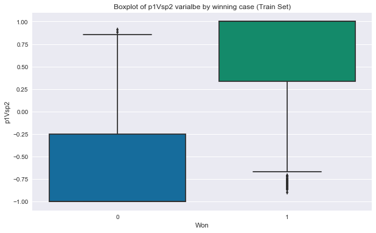

```python
fig, ax = plt.subplots(figsize=(10,6))
bplot = sns.boxplot(y='p1Vsp2', x='Won', data=df_atp_Train, palette="colorblind")
plt.title('Boxplot of p1Vsp2 varialbe by winning case (Train Set)')
```

```
Text(0.5,1,'Boxplot of Wp1Vsp2 varialbe by winning case (Train Set)')
```

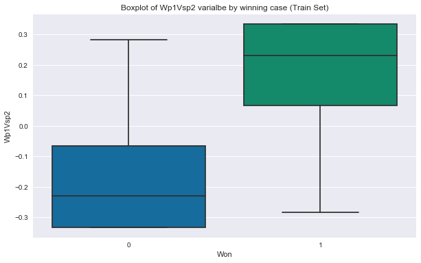

```python
fig, ax = plt.subplots(figsize=(10,6))
bplot = sns.boxplot(y='Wp1Vsp2', x='Won', data=df_atp_Train, palette="colorblind")
plt.title('Boxplot of Wp1Vsp2 varialbe by winning case (Train Set)')
```

We have clearly a great separation between the winning/losing cases from the angle of the two added features 'p1Vsp2' and 'p2Vsp1'

```python
df_atp_Test['p1Vsp2'] = 0
df_atp_Test['Wp1Vsp2'] = 0
```

```python
p1Vsp2(data = df_atp_Test, history = genHistoryTest)
```

```
Computations in progress 0.0%
Computations in progress 10.0%
Computations in progress 20.0%
Computations in progress 30.0%
Computations in progress 40.0%
Computations in progress 50.0%
Computations in progress 60.0%
Computations in progress 70.0%
Computations in progress 80.0%
Computations in progress 90.0%
Computations in progress 100.0%
Done !
```

```python
df_atp_Test.head()
```

|  | Best of | Court | Date | LPts | LRank | Loser | Round | Series | Surface | Tournament | WPts | WRank | Winner | Player1 | Player2 | Won | Year | p1Vsp2 | Wp1Vsp2 |
| --- | --- | --- | --- | --- | --- | --- | --- | --- | --- | --- | --- | --- | --- | --- | --- | --- | --- | --- | --- |
| 47028 | 3 | Outdoor | 2017-01-01 | 372 | 160 | Ymer E. | 1st Round | ATP250 | Hard | Brisbane International | 689 | 79 | Thompson J. | Ymer E. | Thompson J. | 0 | 2017 | 0.000000 | 0.000000 |
| 47029 | 3 | Outdoor | 2017-01-02 | 854 | 54 | Robert S. | 1st Round | ATP250 | Hard | Brisbane International | 1102 | 39 | Mahut N. | Robert S. | Mahut N. | 0 | 2017 | 0.000000 | 0.000000 |
| 47030 | 3 | Outdoor | 2017-01-02 | 1465 | 26 | Tomic B. | 1st Round | ATP250 | Hard | Brisbane International | 1785 | 21 | Ferrer D. | Ferrer D. | Tomic B. | 1 | 2017 | 0.333333 | 0.079365 |
| 47031 | 3 | Outdoor | 2017-01-02 | 443 | 141 | Escobedo E. | 1st Round | ATP250 | Hard | Brisbane International | 1001 | 45 | Edmund K. | Escobedo E. | Edmund K. | 0 | 2017 | -1.000000 | -0.200000 |
| 47032 | 3 | Outdoor | 2017-01-02 | 1320 | 33 | Johnson S. | 1st Round | ATP250 | Hard | Brisbane International | 2035 | 17 | Dimitrov G. | Johnson S. | Dimitrov G. | 0 | 2017 | -0.333333 | -0.106061 |

```
Text(0.5,1,'Boxplot of p1Vsp2 varialbe by winning case (Test Set)')
```

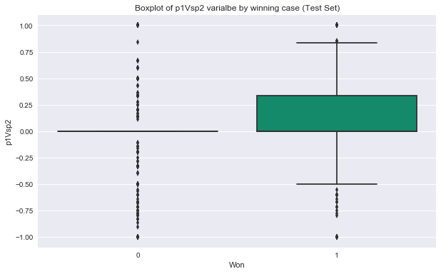

```python
fig, ax = plt.subplots(figsize=(10,6))
bplot = sns.boxplot(y='p1Vsp2', x='Won', data=df_atp_Test, palette="colorblind")
plt.title('Boxplot of p1Vsp2 varialbe by winning case (Test Set)')
```

Separation seems more challenging in the Test set, this will probably lead to some misclassifications in the model.

#### Rank and Points differences (Player1 - Player2)

The two features we're going to introduce are simply the difference between players performances (Points and Ranks).

```python
df_atp_Train["RankDiff"] = 0
df_atp_Train["PtsDiff"] = 0
```

```python
def performanceDiff(variable = 'Rank', targetData=df_atp_Train):
    """
    Overview:
    Computing and filling the difference of a given variable between the two players p1-p2

    Arguments :
    variable : 'Rank' or 'Point'
    targetData : dataframe to be filled with differences (must contain at least the )

    Returns :
    inplace filling of the differences

    """
    if variable == 'Rank':
        Wval, Lval = 'WRank', 'LRank'
        target = "RankDiff"
        differences = targetData[Lval]-targetData[Wval]
    elif variable == 'Point':
        Wval, Lval = 'WPts', 'LPts'
        target = "PtsDiff"
        differences = targetData[Wval]-targetData[Lval]

    targetData[target] = differences
    wonInd1 = targetData['Won'] == 0   #The cases where p1=Loser and p2=Winner
    targetData.loc[wonInd1,target] = targetData.loc[wonInd1,target].apply(lambda x : -x)
```

```python
performanceDiff(variable='Rank', targetData=df_atp_Train)
```

```python
df_atp_Train.head()
```

|  | Best of | Court | Date | LPts | LRank | Loser | Round | Series | Surface | Tournament | ... | WRank | Winner | Player1 | Player2 | Won | Year | p1Vsp2 | Wp1Vsp2 | RankDiff | PtsDiff |
| --- | --- | --- | --- | --- | --- | --- | --- | --- | --- | --- | --- | --- | --- | --- | --- | --- | --- | --- | --- | --- | --- |
| 0 | 3 | Outdoor | 2000-01-03 | 648 | 77 | Ljubicic I. | 1st Round | International | Hard | Australian Hardcourt Championships | ... | 63 | Dosedel S. | Ljubicic I. | Dosedel S. | 0 | 2000 | -1.0 | -0.333333 | -14 | 0 |
| 1 | 3 | Outdoor | 2000-01-03 | 818 | 56 | Clement A. | 1st Round | International | Hard | Australian Hardcourt Championships | ... | 5 | Enqvist T. | Clement A. | Enqvist T. | 0 | 2000 | -0.5 | -0.200000 | -51 | 0 |
| 2 | 3 | Outdoor | 2000-01-03 | 36 | 655 | Baccanello P. | 1st Round | International | Hard | Australian Hardcourt Championships | ... | 40 | Escude N. | Baccanello P. | Escude N. | 0 | 2000 | -1.0 | -0.333333 | -615 | 0 |
| 3 | 3 | Outdoor | 2000-01-03 | 588 | 87 | Knippschild J. | 1st Round | International | Hard | Australian Hardcourt Championships | ... | 65 | Federer R. | Federer R. | Knippschild J. | 1 | 2000 | 1.0 | 0.333333 | 22 | 0 |
| 4 | 3 | Outdoor | 2000-01-03 | 254 | 198 | Woodbridge T. | 1st Round | International | Hard | Australian Hardcourt Championships | ... | 81 | Fromberg R. | Fromberg R. | Woodbridge T. | 1 | 2000 | 1.0 | 0.333333 | 117 | 0 |

5 rows × 21 columns

```python
performanceDiff(variable='Point', targetData=df_atp_Train)
```

```python
df_atp_Train.head()
```

|  | Best of | Court | Date | LPts | LRank | Loser | Round | Series | Surface | Tournament | ... | WRank | Winner | Player1 | Player2 | Won | Year | p1Vsp2 | Wp1Vsp2 | RankDiff | PtsDiff |
| --- | --- | --- | --- | --- | --- | --- | --- | --- | --- | --- | --- | --- | --- | --- | --- | --- | --- | --- | --- | --- | --- |
| 0 | 3 | Outdoor | 2000-01-03 | 648 | 77 | Ljubicic I. | 1st Round | International | Hard | Australian Hardcourt Championships | ... | 63 | Dosedel S. | Ljubicic I. | Dosedel S. | 0 | 2000 | -1.0 | -0.333333 | -14 | -107 |
| 1 | 3 | Outdoor | 2000-01-03 | 818 | 56 | Clement A. | 1st Round | International | Hard | Australian Hardcourt Championships | ... | 5 | Enqvist T. | Clement A. | Enqvist T. | 0 | 2000 | -0.5 | -0.200000 | -51 | -5040 |
| 2 | 3 | Outdoor | 2000-01-03 | 36 | 655 | Baccanello P. | 1st Round | International | Hard | Australian Hardcourt Championships | ... | 40 | Escude N. | Baccanello P. | Escude N. | 0 | 2000 | -1.0 | -0.333333 | -615 | -989 |
| 3 | 3 | Outdoor | 2000-01-03 | 588 | 87 | Knippschild J. | 1st Round | International | Hard | Australian Hardcourt Championships | ... | 65 | Federer R. | Federer R. | Knippschild J. | 1 | 2000 | 1.0 | 0.333333 | 22 | 148 |
| 4 | 3 | Outdoor | 2000-01-03 | 254 | 198 | Woodbridge T. | 1st Round | International | Hard | Australian Hardcourt Championships | ... | 81 | Fromberg R. | Fromberg R. | Woodbridge T. | 1 | 2000 | 1.0 | 0.333333 | 117 | 371 |

5 rows × 21 columns

We do the same thing for the test set.

```python
df_atp_Test["RankDiff"] = 0
df_atp_Test["PtsDiff"] = 0
```

```python
performanceDiff(variable='Rank', targetData=df_atp_Test)
performanceDiff(variable='Point', targetData=df_atp_Test)
```

```python
df_atp_Test.head()
```

|  | Best of | Court | Date | LPts | LRank | Loser | Round | Series | Surface | Tournament | ... | WRank | Winner | Player1 | Player2 | Won | Year | p1Vsp2 | Wp1Vsp2 | RankDiff | PtsDiff |
| --- | --- | --- | --- | --- | --- | --- | --- | --- | --- | --- | --- | --- | --- | --- | --- | --- | --- | --- | --- | --- | --- |
| 47028 | 3 | Outdoor | 2017-01-01 | 372 | 160 | Ymer E. | 1st Round | ATP250 | Hard | Brisbane International | ... | 79 | Thompson J. | Ymer E. | Thompson J. | 0 | 2017 | 0.000000 | 0.000000 | -81 | -317 |
| 47029 | 3 | Outdoor | 2017-01-02 | 854 | 54 | Robert S. | 1st Round | ATP250 | Hard | Brisbane International | ... | 39 | Mahut N. | Robert S. | Mahut N. | 0 | 2017 | 0.000000 | 0.000000 | -15 | -248 |
| 47030 | 3 | Outdoor | 2017-01-02 | 1465 | 26 | Tomic B. | 1st Round | ATP250 | Hard | Brisbane International | ... | 21 | Ferrer D. | Ferrer D. | Tomic B. | 1 | 2017 | 0.333333 | 0.079365 | 5 | 320 |
| 47031 | 3 | Outdoor | 2017-01-02 | 443 | 141 | Escobedo E. | 1st Round | ATP250 | Hard | Brisbane International | ... | 45 | Edmund K. | Escobedo E. | Edmund K. | 0 | 2017 | -1.000000 | -0.200000 | -96 | -558 |
| 47032 | 3 | Outdoor | 2017-01-02 | 1320 | 33 | Johnson S. | 1st Round | ATP250 | Hard | Brisbane International | ... | 17 | Dimitrov G. | Johnson S. | Dimitrov G. | 0 | 2017 | -0.333333 | -0.106061 | -16 | -715 |

5 rows × 21 columns

#### Per Round type winning percentage

```python
uniquePlayers =df_atp_Train.loc[:,['Winner','Loser']].unstack().unique()
```

```python
df_Unique_Players = pd.DataFrame({'Player':uniquePlayers,'FirstRounds':0,
                                  'Quarterfinals':0, 'Semifinals': 0, 'Final':0,
                                 'WeightedSum':0})
genSerie = pd.Series({'1st Round':0, '2nd Round': 0, '3rd Round':0, '4th Round':0,'Quarterfinals':0,'Round Robin':0,
          'Semifinals':0,'The Final':0 })
```

```python
df_Unique_Players.head()
```

|  | Player | FirstRounds | Quarterfinals | Semifinals | Final | WeightedSum |
| --- | --- | --- | --- | --- | --- | --- |
| 0 | Dosedel S. | 0 | 0 | 0 | 0 | 0 |
| 1 | Enqvist T. | 0 | 0 | 0 | 0 | 0 |
| 2 | Escude N. | 0 | 0 | 0 | 0 | 0 |
| 3 | Federer R. | 0 | 0 | 0 | 0 | 0 |
| 4 | Fromberg R. | 0 | 0 | 0 | 0 | 0 |

```python
def roundWin(data = df_atp_Train, genSerie = genSerie, targetData = df_Unique_Players, inplace = True):
    """
    Overview :
    Filling the target data with rounds victories rate per player and per round type.

    #Arguments :
    data : dataframe of players matches having at least the three columns : 'Winner','Loser','Round'
    genSerie : pre-defined Serie with a standard format for local (within function) computations
    targetData : dataframe to be filled with per round and player victories rates
    inplace : boolean, whether to fill the passed target data or return a filled copy.


    #Returns:
    Returns the filled target data (if inplace = False)
    Fills directly the target data passed as argument (if inplace = True)

    """

    progress = 0
    playersLen = len(targetData)
    tenPer, per = playersLen//10, 0

    roundWeights = np.array([0.1,0.2,0.3,0.4,0.6,0,0.7,0.9])  #Weights to be attributed to victories rate per round
                                                              #The weights have ascending values (importance of rounds)

    if(not inplace):
        targetData = targetData.copy()

    for i, player in enumerate(targetData['Player']):
        resultSerie = genSerie.copy()
        playerW = data.loc[data['Winner']==player,'Round']
        playerL = data.loc[data['Loser']==player,'Round']

        perRoundVictories = playerW.value_counts()
        perRoundLosses = playerL.value_counts()

        totalResults = perRoundVictories+perRoundLosses
        victoryFractions = perRoundVictories/totalResults

        resultSerie[victoryFractions.keys()] = victoryFractions
        resultSerie[resultSerie.isna()] = 0

        FirstRounds = np.mean(resultSerie[0:4].values)    #Mean victories rate of the first 4 rounds
        Quarterfinals = resultSerie['Quarterfinals']      #Quarterfinals victories rate
        Semifinals = resultSerie['Semifinals']            #Semifinals victories rate
        Final = resultSerie['The Final']                  #Final victories rate

        weightedVals = np.sum(roundWeights * resultSerie.values)

        targetData.loc[i,'FirstRounds'] = FirstRounds
        targetData.loc[i,'Quarterfinals'] = Quarterfinals
        targetData.loc[i,'Semifinals'] = Semifinals
        targetData.loc[i,'Final'] = Final
        targetData.loc[i,'WeightedSum'] = weightedVals


        if(per==progress):
            print("Computations in progress "+str( np.round(100*per/playersLen, decimals=0))+"%")
            per += tenPer
        progress += 1
        if(progress==playersLen):
            print("Done !")

    if(not inplace):
        return(targetData)
```

```python
roundWin(data = df_atp_Train, genSerie = genSerie, targetData = df_Unique_Players, inplace=True)
```

```
Computations in progress 0.0%
Computations in progress 10.0%
Computations in progress 20.0%
Computations in progress 30.0%
Computations in progress 40.0%
Computations in progress 50.0%
Computations in progress 60.0%
Computations in progress 70.0%
Computations in progress 80.0%
Computations in progress 90.0%
Computations in progress 100.0%
Done !
```

```python
df_Unique_Players.head()
```

|  | Player | FirstRounds | Quarterfinals | Semifinals | Final | WeightedSum |
| --- | --- | --- | --- | --- | --- | --- |
| 0 | Dosedel S. | 0.263393 | 0.000000 | 0.000000 | 0.000000 | 0.192857 |
| 1 | Enqvist T. | 0.461347 | 0.541667 | 0.461538 | 0.500000 | 1.501725 |
| 2 | Escude N. | 0.473575 | 0.450000 | 0.555556 | 0.600000 | 1.594823 |
| 3 | Federer R. | 0.873383 | 0.818627 | 0.750000 | 0.656716 | 2.479830 |
| 4 | Fromberg R. | 0.218833 | 0.500000 | 0.000000 | 0.000000 | 0.433687 |

```python
df_atp_Train['WeightedRndDiff'] = 0   #Depends only on the the two players
df_atp_Train['RoundDiff'] = 0         #depends on the two players + the round of the match
```

```python
def RoundDiff(sourceData = df_Unique_Players, targetData = df_atp_Train, forTestData = False):
    """
    Overview :
    Values Filling of the 'WeightedRndDiff' and 'RoundDiff' features for both train and test set

    Arguments :
    sourceData : dataframe of all players with their corresponding per round victories rate
    targetData : dataframe having at least the 3 features 'Player1','Player2','Round' to be filled
                with players victories rate per round type
    forTestData : boolean, whether it's applied to the test or train data (the main difference is that test data
                  may contain new players with no recorded per round victories rate, we firt add them to a copy
                  of the sourceData with 0 everywhere before filling the target data)

    Returns :
    inPlace filling of 'WeightedRndDiff' and 'RoundDiff' features


    """

    #Test Data Case
    if(forTestData):
        sourceData = sourceData.copy()
        uniquePlayersT =targetData.loc[:,['Winner','Loser']].unstack().unique()
        df_Unique_Players_T = pd.DataFrame({'Player':uniquePlayersT,'FirstRounds':0,
                                  'Quarterfinals':0, 'Semifinals': 0, 'Final':0,
                                 'WeightedSum':0})
        newPlayersInd = df_Unique_Players_T['Player'].apply(lambda x : x not in df_Unique_Players['Player'].values)
        df_Unique_Players_T = df_Unique_Players_T.loc[newPlayersInd,:]
        sourceData = pd.concat([df_Unique_Players,df_Unique_Players_T], axis=0)


    progress = 0
    playersLen = len(targetData)
    tenPer, per = playersLen//10, 0

    for i in range(len(targetData)):
        p1 = targetData.loc[targetData.index[i],'Player1']
        p2 = targetData.loc[targetData.index[i],'Player2']
        matchRound = targetData.loc[targetData.index[i],'Round']

        wSump1 = sourceData.loc[sourceData['Player']==p1,'WeightedSum']
        wSump2 = sourceData.loc[sourceData['Player']==p2,'WeightedSum']


        diffW = wSump1.values - wSump2.values
        targetData.loc[targetData.index[i],'WeightedRndDiff'] = diffW

        if 'Round' in matchRound:
            roundValP1 = sourceData.loc[sourceData['Player']==p1,'FirstRounds']
            roundValP2 = sourceData.loc[sourceData['Player']==p2,'FirstRounds']
        elif matchRound == 'Quarterfinals':
            roundValP1 = sourceData.loc[sourceData['Player']==p1,'Quarterfinals']
            roundValP2 = sourceData.loc[sourceData['Player']==p2,'Quarterfinals']
        elif matchRound == 'Semifinals':
            roundValP1 = sourceData.loc[sourceData['Player']==p1,'Semifinals']
            roundValP2 = sourceData.loc[sourceData['Player']==p2,'Semifinals']
        elif matchRound == 'The Final':
            roundValP1 = sourceData.loc[sourceData['Player']==p1,'Final']
            roundValP2 = sourceData.loc[sourceData['Player']==p2,'Final']
        else:
            roundValP1 = wSump1
            roundValP2 = wSump2

        diff = roundValP1.values - roundValP2.values
        targetData.loc[targetData.index[i],'RoundDiff'] = diff


        if(per==progress):
            print("Computations in progress "+str( np.round(100*per/playersLen, decimals=0))+"%")
            per += tenPer
        progress += 1
        if(progress==playersLen):
            print("Done !")
```

```python
RoundDiff(sourceData = df_Unique_Players, targetData = df_atp_Train)
```

```
Computations in progress 0.0%
Computations in progress 10.0%
Computations in progress 20.0%
Computations in progress 30.0%
Computations in progress 40.0%
Computations in progress 50.0%
Computations in progress 60.0%
Computations in progress 70.0%
Computations in progress 80.0%
Computations in progress 90.0%
Computations in progress 100.0%
Done !
```

```python
df_atp_Train.head()
```

|  | Best of | Court | Date | LPts | LRank | Loser | Round | Series | Surface | Tournament | ... | Player1 | Player2 | Won | Year | p1Vsp2 | Wp1Vsp2 | RankDiff | PtsDiff | WeightedRndDiff | RoundDiff |
| --- | --- | --- | --- | --- | --- | --- | --- | --- | --- | --- | --- | --- | --- | --- | --- | --- | --- | --- | --- | --- | --- |
| 0 | 3 | Outdoor | 2000-01-03 | 648 | 77 | Ljubicic I. | 1st Round | International | Hard | Australian Hardcourt Championships | ... | Ljubicic I. | Dosedel S. | 0 | 2000 | -1.0 | -0.333333 | -14 | -107 | 1.471255 | 0.341504 |
| 1 | 3 | Outdoor | 2000-01-03 | 818 | 56 | Clement A. | 1st Round | International | Hard | Australian Hardcourt Championships | ... | Clement A. | Enqvist T. | 0 | 2000 | -0.5 | -0.200000 | -51 | -5040 | -0.062583 | -0.003199 |
| 2 | 3 | Outdoor | 2000-01-03 | 36 | 655 | Baccanello P. | 1st Round | International | Hard | Australian Hardcourt Championships | ... | Baccanello P. | Escude N. | 0 | 2000 | -1.0 | -0.333333 | -615 | -989 | -1.566251 | -0.402146 |
| 3 | 3 | Outdoor | 2000-01-03 | 588 | 87 | Knippschild J. | 1st Round | International | Hard | Australian Hardcourt Championships | ... | Federer R. | Knippschild J. | 1 | 2000 | 1.0 | 0.333333 | 22 | 148 | 2.422362 | 0.752442 |
| 4 | 3 | Outdoor | 2000-01-03 | 254 | 198 | Woodbridge T. | 1st Round | International | Hard | Australian Hardcourt Championships | ... | Fromberg R. | Woodbridge T. | 1 | 2000 | 1.0 | 0.333333 | 117 | 371 | 0.346782 | 0.037285 |

5 rows × 23 columns

Let's visualize some scatter plots labeled with the output value (0-1) to see the effect of the added features related to performance difference :

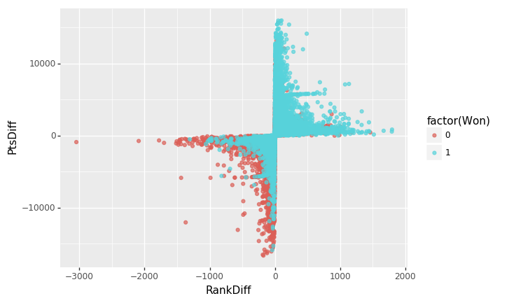

```python
pln.ggplot(data=df_atp_Train,mapping= pln.aes(x='RankDiff',y='PtsDiff', colour='factor(Won)'))+pln.geom_point(alpha=0.7)
```

We do the same for test data (based on computed values of the train examples of course)

```python
df_atp_Test['WeightedRndDiff'] = 0   #Depends only on the the two players
df_atp_Test['RoundDiff'] = 0         #depends on the two players + the round of the match
```

```python
RoundDiff(sourceData = df_Unique_Players, targetData = df_atp_Test, forTestData=True)
```

```
Computations in progress 0.0%
Computations in progress 10.0%
Computations in progress 20.0%
Computations in progress 30.0%
Computations in progress 40.0%
Computations in progress 50.0%
Computations in progress 60.0%
Computations in progress 70.0%
Computations in progress 80.0%
Computations in progress 90.0%
Computations in progress 100.0%
Done !
```

```python
df_atp_Train.head()
```

|  | Best of | Court | Date | LPts | LRank | Loser | Round | Series | Surface | Tournament | ... | Player1 | Player2 | Won | Year | p1Vsp2 | Wp1Vsp2 | RankDiff | PtsDiff | WeightedRndDiff | RoundDiff |
| --- | --- | --- | --- | --- | --- | --- | --- | --- | --- | --- | --- | --- | --- | --- | --- | --- | --- | --- | --- | --- | --- |
| 0 | 3 | Outdoor | 2000-01-03 | 648 | 77 | Ljubicic I. | 1st Round | International | Hard | Australian Hardcourt Championships | ... | Ljubicic I. | Dosedel S. | 0 | 2000 | -1.0 | -0.333333 | -14 | -107 | 1.471255 | 0.341504 |
| 1 | 3 | Outdoor | 2000-01-03 | 818 | 56 | Clement A. | 1st Round | International | Hard | Australian Hardcourt Championships | ... | Clement A. | Enqvist T. | 0 | 2000 | -0.5 | -0.200000 | -51 | -5040 | -0.062583 | -0.003199 |
| 2 | 3 | Outdoor | 2000-01-03 | 36 | 655 | Baccanello P. | 1st Round | International | Hard | Australian Hardcourt Championships | ... | Baccanello P. | Escude N. | 0 | 2000 | -1.0 | -0.333333 | -615 | -989 | -1.566251 | -0.402146 |
| 3 | 3 | Outdoor | 2000-01-03 | 588 | 87 | Knippschild J. | 1st Round | International | Hard | Australian Hardcourt Championships | ... | Federer R. | Knippschild J. | 1 | 2000 | 1.0 | 0.333333 | 22 | 148 | 2.422362 | 0.752442 |
| 4 | 3 | Outdoor | 2000-01-03 | 254 | 198 | Woodbridge T. | 1st Round | International | Hard | Australian Hardcourt Championships | ... | Fromberg R. | Woodbridge T. | 1 | 2000 | 1.0 | 0.333333 | 117 | 371 | 0.346782 | 0.037285 |

5 rows × 23 columns

## Modeling

```python
df_atp_Train.columns
```

```
Index(['Best of', 'Court', 'Date', 'LPts', 'LRank', 'Loser', 'Round', 'Series',
       'Surface', 'Tournament', 'WPts', 'WRank', 'Winner', 'Player1',
       'Player2', 'Won', 'Year', 'p1Vsp2', 'Wp1Vsp2', 'RankDiff', 'PtsDiff',
       'WeightedRndDiff', 'RoundDiff'],
      dtype='object')
```

```python
featuresCols = np.array(['Won','Year','Court','Round','Surface','RankDiff','PtsDiff','WeightedRndDiff','RoundDiff' ])
```

```python
TrainData = df_atp_Train.loc[:,featuresCols].copy()
TrainX = TrainData.loc[:,'Won'!=featuresCols]
TrainY = TrainData.loc[:,'Won']

TestData = df_atp_Test.loc[:,featuresCols].copy()
TestX = TestData.loc[:,'Won'!=featuresCols]
TestY = TestData.loc[:,'Won']
```

```python
df_atp_Train.to_csv(date_format='%Y-%m-%d',header=True, path_or_buf='ATPTrain.csv')
df_atp_Test.to_csv(date_format='%Y-%m-%d',header=True, path_or_buf='ATPTest.csv')
```

#### Categorical variables to dummy variables

```python
from sklearn import preprocessing
from sklearn.metrics import classification_report, confusion_matrix
```

```python
TrainX.columns
```

```
Index(['Year', 'Court', 'Round', 'Surface', 'RankDiff', 'PtsDiff',
       'WeightedRndDiff', 'RoundDiff'],
      dtype='object')
```

```python
courtCats = TrainX.Court.unique()
CourtCat = pd.DataFrame({'CourtCat':TrainX.Court.unique()})
CourtCat
```

|  | CourtCat |
| --- | --- |
| 0 | Outdoor |
| 1 | Indoor |

```python
surfCats = TrainX.Surface.unique()
SurfaceCategories = pd.DataFrame({'SurfaceCat':TrainX.Surface.unique()})
SurfaceCategories
```

|  | SurfaceCat |
| --- | --- |
| 0 | Hard |
| 1 | Clay |
| 2 | Grass |
| 3 | Carpet |

```python
roundCats = TrainX.Round.unique()
RoundCategories = pd.DataFrame({'RoundCat':TrainX.Round.unique()})
RoundCategories
```

|  | RoundCat |
| --- | --- |
| 0 | 1st Round |
| 1 | 2nd Round |
| 2 | Quarterfinals |
| 3 | Semifinals |
| 4 | The Final |
| 5 | 3rd Round |
| 6 | 4th Round |
| 7 | Round Robin |

We turn these features into 0-1 encoding (Dummy variables)

```python
surfaceDummiesTrain = pd.get_dummies(TrainX,columns= np.array(['Surface']), prefix='', prefix_sep='')
surfaceDummiesTrain = surfaceDummiesTrain.T.reindex(surfCats).T.fillna(0)
surfaceDummiesTrain = surfaceDummiesTrain.loc[:,surfCats]
```

```python
surfaceDummiesTest = pd.get_dummies(TestX,columns= np.array(['Surface']), prefix='', prefix_sep='')
surfaceDummiesTest = surfaceDummiesTest.T.reindex(surfCats).T.fillna(0)
surfaceDummiesTest = surfaceDummiesTest.loc[:,surfCats]
```

```python
courtDummiesTrain = pd.get_dummies(TrainX,columns= np.array(['Court']), prefix='', prefix_sep='')
courtDummiesTrain = courtDummiesTrain.T.reindex(courtCats).T.fillna(0)
courtDummiesTrain = courtDummiesTrain.loc[:,courtCats]
```

```python
courtDummiesTest = pd.get_dummies(TestX,columns= np.array(['Court']), prefix='', prefix_sep='')
courtDummiesTest = courtDummiesTest.T.reindex(courtCats).T.fillna(0)
courtDummiesTest = courtDummiesTest.loc[:,courtCats]
```

```python
roundDummiesTrain = pd.get_dummies(TrainX,columns= np.array(['Round']), prefix='', prefix_sep='')
roundDummiesTrain = roundDummiesTrain.T.reindex(roundCats).T.fillna(0)
roundDummiesTrain = roundDummiesTrain.loc[:,roundCats]
```

```python
roundDummiesTest = pd.get_dummies(TestX,columns= np.array(['Round']), prefix='', prefix_sep='')
roundDummiesTest = roundDummiesTest.T.reindex(roundCats).T.fillna(0)
roundDummiesTest = roundDummiesTest.loc[:,roundCats]
```

```python
#Concatenate the whole
TrainX = pd.concat([TrainX, surfaceDummiesTrain, courtDummiesTrain, roundDummiesTrain], axis=1)
```

```python
TrainX.head()
```

|  | Year | Court | Round | Surface | RankDiff | PtsDiff | WeightedRndDiff | RoundDiff | Hard | Clay | ... | Outdoor | Indoor | 1st Round | 2nd Round | Quarterfinals | Semifinals | The Final | 3rd Round | 4th Round | Round Robin |
| --- | --- | --- | --- | --- | --- | --- | --- | --- | --- | --- | --- | --- | --- | --- | --- | --- | --- | --- | --- | --- | --- |
| 0 | 2000 | Outdoor | 1st Round | Hard | -14 | -107 | 1.471255 | 0.341504 | 1 | 0 | ... | 1 | 0 | 1 | 0 | 0 | 0 | 0 | 0 | 0 | 0 |
| 1 | 2000 | Outdoor | 1st Round | Hard | -51 | -5040 | -0.062583 | -0.003199 | 1 | 0 | ... | 1 | 0 | 1 | 0 | 0 | 0 | 0 | 0 | 0 | 0 |
| 2 | 2000 | Outdoor | 1st Round | Hard | -615 | -989 | -1.566251 | -0.402146 | 1 | 0 | ... | 1 | 0 | 1 | 0 | 0 | 0 | 0 | 0 | 0 | 0 |
| 3 | 2000 | Outdoor | 1st Round | Hard | 22 | 148 | 2.422362 | 0.752442 | 1 | 0 | ... | 1 | 0 | 1 | 0 | 0 | 0 | 0 | 0 | 0 | 0 |
| 4 | 2000 | Outdoor | 1st Round | Hard | 117 | 371 | 0.346782 | 0.037285 | 1 | 0 | ... | 1 | 0 | 1 | 0 | 0 | 0 | 0 | 0 | 0 | 0 |

5 rows × 22 columns

```python
TestX = pd.concat([TestX, surfaceDummiesTest, courtDummiesTest, roundDummiesTest], axis=1)
```

```python
TestX.head()
```

|  | Year | Court | Round | Surface | RankDiff | PtsDiff | WeightedRndDiff | RoundDiff | Hard | Clay | ... | Outdoor | Indoor | 1st Round | 2nd Round | Quarterfinals | Semifinals | The Final | 3rd Round | 4th Round | Round Robin |
| --- | --- | --- | --- | --- | --- | --- | --- | --- | --- | --- | --- | --- | --- | --- | --- | --- | --- | --- | --- | --- | --- |
| 47028 | 2017 | Outdoor | 1st Round | Hard | -81 | -317 | 0.094949 | 0.112374 | 1 | 0 | ... | 1 | 0 | 1 | 0 | 0 | 0 | 0 | 0 | 0 | 0 |
| 47029 | 2017 | Outdoor | 1st Round | Hard | -15 | -248 | -1.052684 | -0.021857 | 1 | 0 | ... | 1 | 0 | 1 | 0 | 0 | 0 | 0 | 0 | 0 | 0 |
| 47030 | 2017 | Outdoor | 1st Round | Hard | 5 | 320 | 0.376746 | 0.248541 | 1 | 0 | ... | 1 | 0 | 1 | 0 | 0 | 0 | 0 | 0 | 0 | 0 |
| 47031 | 2017 | Outdoor | 1st Round | Hard | -96 | -558 | -0.216590 | -0.077189 | 1 | 0 | ... | 1 | 0 | 1 | 0 | 0 | 0 | 0 | 0 | 0 | 0 |
| 47032 | 2017 | Outdoor | 1st Round | Hard | -16 | -715 | -0.293613 | -0.136051 | 1 | 0 | ... | 1 | 0 | 1 | 0 | 0 | 0 | 0 | 0 | 0 | 0 |

5 rows × 22 columns

```python
TrainX.drop(axis=1,columns=['Court','Surface', 'Round'], inplace=True)
```

```python
TestX.drop(axis=1,columns=['Court','Surface','Round'], inplace=True)
```

# Modeling

We will use a random forest implementation in sklearn to fit our model, with some hyper-parameters tuning for a better estimation of the optimal model.

```python
#Import Random Forest Model
from sklearn.ensemble import RandomForestClassifier , AdaBoostClassifier, GradientBoostingClassifier
from sklearn.model_selection import RandomizedSearchCV, GridSearchCV
from sklearn.tree import DecisionTreeClassifier
```

### Random Forest

```python
rf_Fit0=RandomForestClassifier(n_estimators=1000, random_state=1995, min_samples_leaf=20, max_features=9, criterion='gini' )
```

```python
rf_Fit0.fit(TrainX,TrainY)
```

```
RandomForestClassifier(bootstrap=True, class_weight=None, criterion='gini',
            max_depth=None, max_features=9, max_leaf_nodes=None,
            min_impurity_decrease=0.0, min_impurity_split=None,
            min_samples_leaf=20, min_samples_split=2,
            min_weight_fraction_leaf=0.0, n_estimators=1000, n_jobs=1,
            oob_score=False, random_state=1995, verbose=0,
            warm_start=False)
```

```python
rf_pred = rf_Fit0.predict(TestX)
```

```python
rf_Fit0.score(TestX, TestY)
```

```
0.6444022770398482
```

### Tuning Random Forest

```python
#Number of trees in random forest
n_estimators = np.linspace(start = 1200, stop = 3000, num = 10, dtype='int32')
#Number of features to consider at every split
max_features = [5,6,7,8,10]
#Maximum number of levels in tree
max_depth = list(np.linspace(30, 80, num = 5, dtype='int32'))
max_depth.append(None)
#Minimum number of samples required to split a node
min_samples_split = [10, 50, 80]
#Minimum number of samples required at each leaf node
min_samples_leaf = [5, 10, 40]
#Method of selecting samples for training each tree
bootstrap = [True, False]
#Information critereon
criterion=['gini']
```

```python
# Random grid
random_grid = {'n_estimators': n_estimators,
               'max_features': max_features,
               'max_depth': max_depth,
               'min_samples_split': min_samples_split,
               'min_samples_leaf': min_samples_leaf,
               'bootstrap': bootstrap,
               'criterion' : criterion
              }
```

```python
# Random forest Base model to tune
rf_fit = RandomForestClassifier()
```

```python
rf_random_fit = RandomizedSearchCV(estimator = rf_fit, param_distributions = random_grid, n_iter = 30, cv = 3, random_state=1995, n_jobs = -1)
```

```python
TrainY = TrainY.squeeze()
```

```python
# Fit the random search model
rf_random_fit.fit(TrainX, TrainY)
```

```
RandomizedSearchCV(cv=3, error_score='raise',
          estimator=RandomForestClassifier(bootstrap=True, class_weight=None, criterion='gini',
            max_depth=None, max_features='auto', max_leaf_nodes=None,
            min_impurity_decrease=0.0, min_impurity_split=None,
            min_samples_leaf=1, min_samples_split=2,
            min_weight_fraction_leaf=0.0, n_estimators=10, n_jobs=1,
            oob_score=False, random_state=None, verbose=0,
            warm_start=False),
          fit_params=None, iid=True, n_iter=30, n_jobs=-1,
          param_distributions={'n_estimators': array([1200, 1400, 1600, 1800, 2000, 2200, 2400, 2600, 2800, 3000],
      dtype=int32), 'max_features': [5, 6, 7, 8, 10], 'max_depth': [30, 42, 55, 67, 80, None], 'min_samples_split': [10, 50, 80], 'min_samples_leaf': [5, 10, 40], 'bootstrap': [True, False], 'criterion': ['gini']},
          pre_dispatch='2*n_jobs', random_state=1995, refit=True,
          return_train_score='warn', scoring=None, verbose=0)
```

```python
best_rf = rf_random_fit.best_estimator_
```

```python
best_rf
```

```
RandomForestClassifier(bootstrap=True, class_weight=None, criterion='gini',
            max_depth=67, max_features=5, max_leaf_nodes=None,
            min_impurity_decrease=0.0, min_impurity_split=None,
            min_samples_leaf=40, min_samples_split=80,
            min_weight_fraction_leaf=0.0, n_estimators=2600, n_jobs=1,
            oob_score=False, random_state=None, verbose=0,
            warm_start=False)
```

```python
best_rf.score(X=TestX,y=TestY)
```

```
0.6432637571157496
```

```python
feature_imp = pd.Series(best_rf.feature_importances_, index=TrainX.columns).sort_values(ascending=False)
```

```
Text(0.5,1,'Features importance in the optimal Random Forest estimator')
```

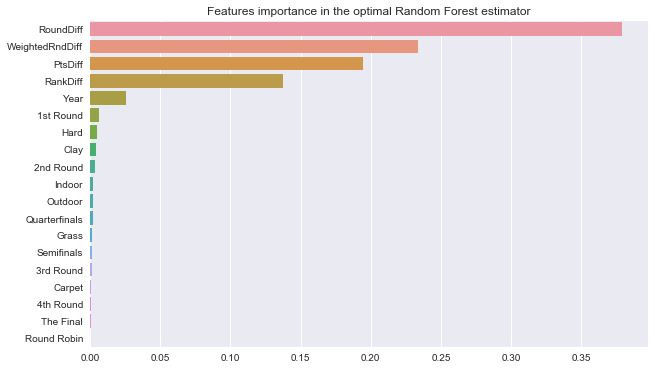

```python
fig, ax = plt.subplots(figsize=(10,6))
sns.barplot(x=feature_imp, y=feature_imp.index)
plt.title('Features importance in the optimal Random Forest estimator')
```

```python
bestPredictions = best_rf.predict(TestX)
```

```python
bestPredictions = bestPredictions.reshape((len(bestPredictions),1))
```

```python
trueValues = np.array(TestY).reshape((len(TestY),1))
```

```python
#Confusion matrix
confusion_matrix(y_pred=bestPredictions, y_true=trueValues)
```

```
array([[872, 482],
       [458, 823]])
```

The accuracy of 64% we've got is somewhat mediocre and can be explained by the fact that the nature of the problem is not an ordinary ML task since it includes the Time factor that we didn't explore using Time Series technics. The lack of further features is also a crucial factor, and eventhough we were able to use betting data and that would increase significantly with no doubt our prediction accuracy, the idea itself lacks honesty because it's the output of other peoples' models, and thus it doesn't make sense to use it and pretend having built a realistic ML model.